# Contract Exercised Options

### 03B: Interaction

Expectation: As the number of contract actions a vendor has performed for an office in the past year increases (decreases), the likelihood of cost ceiling breaches and terminations decreases (increases) and that of exercised options increases (decreases) for that partnership.

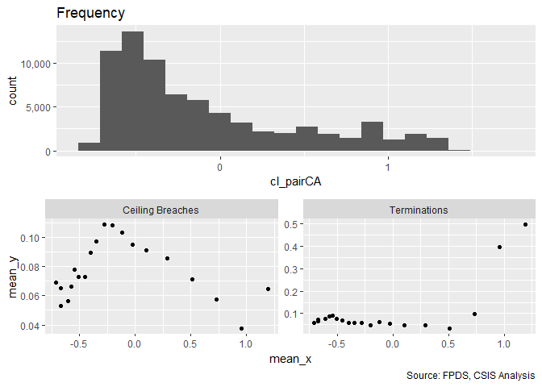

```r
 # !is.na(def_serv$cl_US6_avg_sal_lag1)&
 #  !is.na(def_serv$cl_CFTE)&
 #  !is.na(def_serv$c_pPBSC)&
 #  !is.na(def_serv$c_pOffPSC)&
 #  !is.na(def_serv$c_pairHist)&
 #  !is.na(def_serv$cl_pairCA)&

summary_continuous_plot(serv_opt,"cl_pairCA")
```

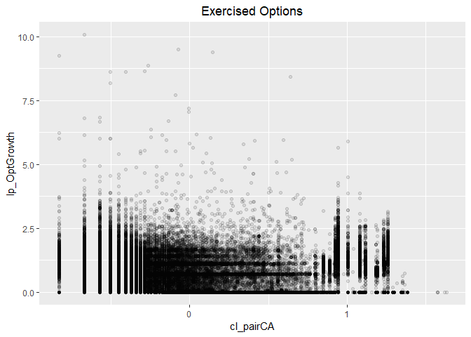

```r
#Scatter Plot
ggplot(serv_opt, aes(x=cl_pairCA, y=lp_OptGrowth)) + geom_point(alpha = 0.1) + ggtitle('Exercised Options') + theme(plot.title = element_text(hjust = 0.5))
```

```r
#Model
n_Opt_03B <- glm (data=serv_opt,
                 ln_OptGrowth ~ cl_pairCA)
display(n_Opt_03B)
```

```
## glm(formula = ln_OptGrowth ~ cl_pairCA, data = serv_opt)
##             coef.est coef.se
## (Intercept)  7.08     0.02
## cl_pairCA   -1.35     0.04
## ---
##   n = 74162, k = 2
##   residual deviance = 2543508.0, null deviance = 2585789.3 (difference = 42281.2)
##   overdispersion parameter = 34.3
##   residual sd is sqrt(overdispersion) = 5.86
```

```r
p_Opt_03B <- glm(data=serv_opt,
                        lp_OptGrowth ~ cl_pairCA)

display(p_Opt_03B)
```

```
## glm(formula = lp_OptGrowth ~ cl_pairCA, data = serv_opt)
##             coef.est coef.se
## (Intercept)  0.64     0.00
## cl_pairCA   -0.04     0.00
## ---
##   n = 74162, k = 2
##   residual deviance = 34911.5, null deviance = 34944.5 (difference = 33.0)
##   overdispersion parameter = 0.5
##   residual sd is sqrt(overdispersion) = 0.69
```

```r
#Plot residuals versus fitted
stargazer::stargazer(n_Opt_02D,n_Opt_03A,n_Opt_03B,

                       p_Opt_02D,p_Opt_03A,p_Opt_03B,
                       type="text",
                       digits=2)
```

```
##
## =============================================================================================
##                                                  Dependent variable:
##                          --------------------------------------------------------------------
##                                     ln_OptGrowth                       lp_OptGrowth
##                              (1)         (2)         (3)        (4)        (5)        (6)
## ---------------------------------------------------------------------------------------------
## cl_US6_avg_sal_lag1Const   0.71***                            -0.03***
##                            (0.05)                              (0.01)
##
## cl_CFTE                   -0.82***                            -0.14***
##                            (0.06)                              (0.01)
##
## c_pPBSC                   -0.52***                            -0.05***
##                            (0.05)                              (0.01)
##
## c_pOffPSC                 -0.24***                            0.17***
##                            (0.05)                              (0.01)
##
## c_pairHist                            -0.61***                           -0.04***
##                                        (0.04)                            (0.005)
##
## cl_pairCA                                         -1.35***                          -0.04***
##                                                    (0.04)                           (0.005)
##
## Constant                   7.22***     7.19***     7.08***    0.65***    0.64***    0.64***
##                            (0.02)      (0.02)      (0.02)     (0.003)    (0.003)    (0.003)
##
## ---------------------------------------------------------------------------------------------
## Observations               74,162      74,162      74,162      74,162     74,162     74,162
## Log Likelihood           -236,701.90 -236,816.30 -236,315.40 -76,611.39 -77,288.54 -77,294.15
## Akaike Inf. Crit.        473,413.90  473,636.60  472,634.80  153,232.80 154,581.10 154,592.30
## =============================================================================================
## Note:                                                             *p<0.1; **p<0.05; ***p<0.01
```

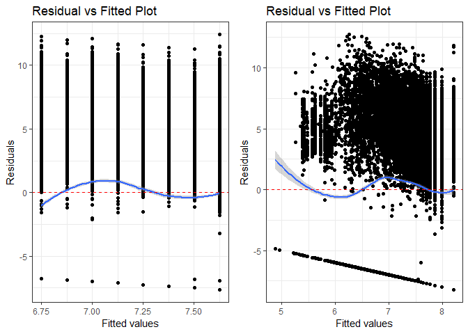

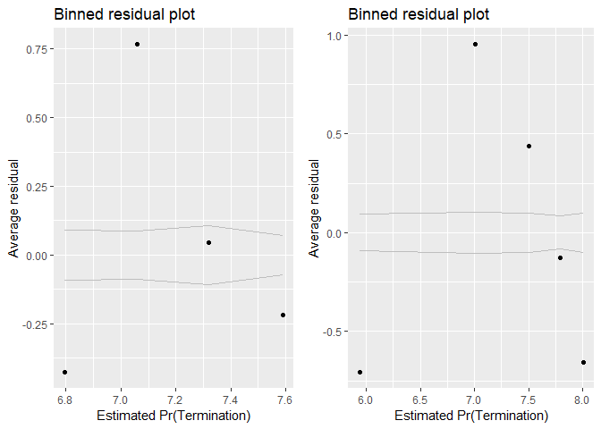

```r
summary_residual_compare(n_Opt_03A,n_Opt_03B, skip_vif = TRUE)
```

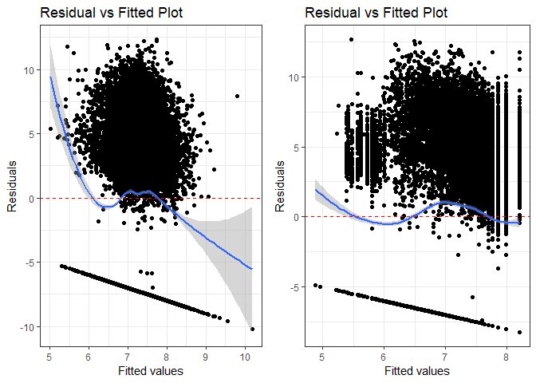

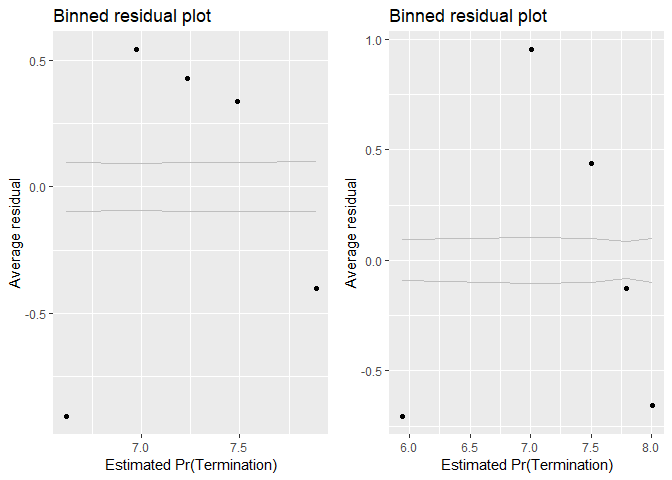

```r
summary_residual_compare(n_Opt_02D,n_Opt_03B, skip_vif = TRUE)
```

When considering contract actions alone, no expectation were met. The patterns in the plots are complex, ceiling breaches has a sinusoidal or perhaps exponential relationship while terminations has an neative relationship, until the number of ations grows extreme at which point the risk jumps up.

### 03C: Office-Vendor Relationship

Expectation: The importance of partnership, trust, and handling difficult problems and uncertainty together naturally lead into the last characteristic: the relationship between the contractor and buyer. The higher level of interaction provides the more opportunity to build a deeper relationship, the likelihood of cost ceiling breaches and terminations decreases and the exercised options increase for that partnership. Also we expect the result of combined model would be the same as individual models above.

```r
 # !is.na(def_serv$cl_US6_avg_sal_lag1)&
 #  !is.na(def_serv$cl_CFTE)&
 #  !is.na(def_serv$c_pPBSC)&
 #  !is.na(def_serv$c_pOffPSC)&
 #  !is.na(def_serv$c_pairHist)&
 #  !is.na(def_serv$cl_pairCA)&

#Model
n_Opt_03C <- glm (data=serv_opt,
                 ln_OptGrowth ~ c_pairHist+cl_pairCA)
glmer_examine(n_Opt_03C)
```

```
## c_pairHist  cl_pairCA
##   1.417674   1.417674
```

```r
p_Opt_03C <- glm(data=serv_opt,
                        lp_OptGrowth ~ c_pairHist+cl_pairCA)

glmer_examine(p_Opt_03C)
```

```
## c_pairHist  cl_pairCA
##   1.417674   1.417674
```

```r
#Plot residuals versus fitted
  stargazer::stargazer(n_Opt_02D,n_Opt_03A,n_Opt_03B,n_Opt_03C,

                       p_Opt_02D,p_Opt_03A,p_Opt_03B,p_Opt_03C,
                       type="text",
                       digits=2)
```

```
##
## ====================================================================================================================
##                                                              Dependent variable:
##                          -------------------------------------------------------------------------------------------
##                                           ln_OptGrowth                                  lp_OptGrowth
##                              (1)         (2)         (3)         (4)        (5)        (6)        (7)        (8)
## --------------------------------------------------------------------------------------------------------------------
## cl_US6_avg_sal_lag1Const   0.71***                                        -0.03***
##                            (0.05)                                          (0.01)
##
## cl_CFTE                   -0.82***                                        -0.14***
##                            (0.06)                                          (0.01)
##
## c_pPBSC                   -0.52***                                        -0.05***
##                            (0.05)                                          (0.01)
##
## c_pOffPSC                 -0.24***                                        0.17***
##                            (0.05)                                          (0.01)
##
## c_pairHist                            -0.61***                 0.23***               -0.04***              -0.03***
##                                        (0.04)                  (0.05)                (0.005)                (0.01)
##
## cl_pairCA                                         -1.35***    -1.47***                          -0.04***   -0.02***
##                                                    (0.04)      (0.05)                           (0.005)     (0.01)
##
## Constant                   7.22***     7.19***     7.08***     7.09***    0.65***    0.64***    0.64***    0.64***
##                            (0.02)      (0.02)      (0.02)      (0.02)     (0.003)    (0.003)    (0.003)    (0.003)
##
## --------------------------------------------------------------------------------------------------------------------
## Observations               74,162      74,162      74,162      74,162      74,162     74,162     74,162     74,162
## Log Likelihood           -236,701.90 -236,816.30 -236,315.40 -236,303.60 -76,611.39 -77,288.54 -77,294.15 -77,279.95
## Akaike Inf. Crit.        473,413.90  473,636.60  472,634.80  472,613.20  153,232.80 154,581.10 154,592.30 154,565.90
## ====================================================================================================================
## Note:                                                                                    *p<0.1; **p<0.05; ***p<0.01
```

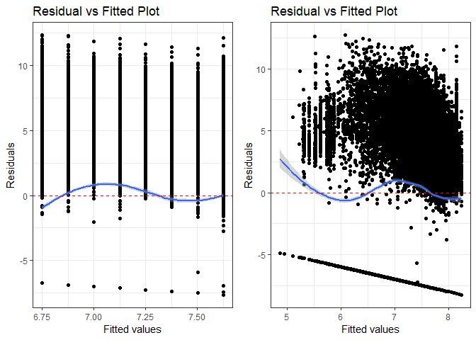

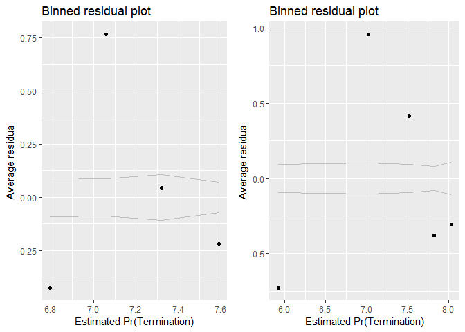

```
## [[1]]
##        model deviance null.deviance difference
## 1 model1_old  2578099       2585789   7690.044
## 2 model1_new  2542697       2585789  43092.210
##
## [[2]]
## c_pairHist  cl_pairCA
##   1.417674   1.417674
```

```r
summary_residual_compare(n_Opt_03A,n_Opt_03C)
```

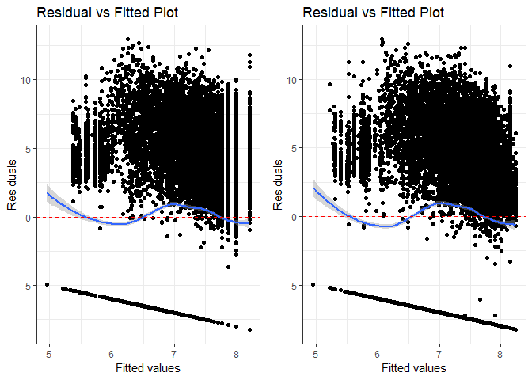

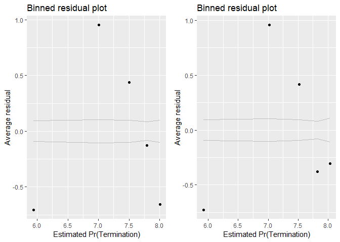

```
## [[1]]
##        model deviance null.deviance difference
## 1 model1_old  2543508       2585789   42281.24
## 2 model1_new  2542697       2585789   43092.21
##
## [[2]]
## c_pairHist  cl_pairCA
##   1.417674   1.417674
```

```r
summary_residual_compare(n_Opt_03B,n_Opt_03C)
```

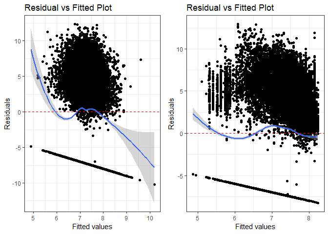

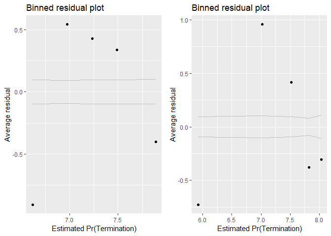

```
## [[1]]
##        model deviance null.deviance difference
## 1 model1_old  2570160       2585789   15629.63
## 2 model1_new  2542697       2585789   43092.21
##
## [[2]]
## c_pairHist  cl_pairCA
##   1.417674   1.417674
```

```r
summary_residual_compare(n_Opt_02D,n_Opt_03C)
```

### 03D: Cumulative Model

Expectation: Under each subgroup, the predictors are expected to have similar impacts on dependent variables individually and cumulatively: 1. Higher Services Complexity: Higher likelihood of cost ceiling breaches and terminations; Less exercised options 2. Larger Office Capacity: Lower likelihood of cost ceiling breaches and terminations; More exercised options 3. Deeper Office-Vendor Relationship: Lower likelihood of cost ceiling breaches and terminations; More exercised options

```r
#Model
n_Opt_03D <- glm (data=serv_opt,
                 ln_OptGrowth ~  cl_US6_avg_sal_lag1Const +
                   cl_CFTE+ c_pPBSC+c_pOffPSC+
                 c_pairHist+cl_pairCA)
glmer_examine(n_Opt_03D)
```

```
## cl_US6_avg_sal_lag1Const                  cl_CFTE                  c_pPBSC
##                 1.485861                 1.470224                 1.135510
##                c_pOffPSC               c_pairHist                cl_pairCA
##                 1.719197                 1.445773                 2.175117
```

```r
p_Opt_03D <- glm(data=serv_opt,
                        lp_OptGrowth ~  cl_US6_avg_sal_lag1Const +
                   cl_CFTE+ c_pPBSC+c_pOffPSC+
                 c_pairHist+cl_pairCA)

glmer_examine(p_Opt_03D)
```

```
## cl_US6_avg_sal_lag1Const                  cl_CFTE                  c_pPBSC
##                 1.485861                 1.470224                 1.135510
##                c_pOffPSC               c_pairHist                cl_pairCA
##                 1.719197                 1.445773                 2.175117
```

```r
#Plot residuals versus fitted

stargazer::stargazer(n_Opt_02D,n_Opt_03C,n_Opt_03D,

                       p_Opt_02D,p_Opt_03C,p_Opt_03D,
                       type="text",
                       digits=2)
```

```
##
## =============================================================================================
##                                                  Dependent variable:
##                          --------------------------------------------------------------------
##                                     ln_OptGrowth                       lp_OptGrowth
##                              (1)         (2)         (3)        (4)        (5)        (6)
## ---------------------------------------------------------------------------------------------
## cl_US6_avg_sal_lag1Const   0.71***                 0.82***    -0.03***              -0.02***
##                            (0.05)                  (0.05)      (0.01)                (0.01)
##
## cl_CFTE                   -0.82***                -0.73***    -0.14***              -0.13***
##                            (0.06)                  (0.06)      (0.01)                (0.01)
##
## c_pPBSC                   -0.52***                -0.35***    -0.05***              -0.03***
##                            (0.05)                  (0.05)      (0.01)                (0.01)
##
## c_pOffPSC                 -0.24***                 1.31***    0.17***               0.28***
##                            (0.05)                  (0.07)      (0.01)                (0.01)
##
## c_pairHist                             0.23***     0.34***               -0.03***    -0.001
##                                        (0.05)      (0.05)                 (0.01)     (0.01)
##
## cl_pairCA                             -1.47***    -2.14***               -0.02***   -0.13***
##                                        (0.05)      (0.06)                 (0.01)     (0.01)
##
## Constant                   7.22***     7.09***     7.01***    0.65***    0.64***    0.64***
##                            (0.02)      (0.02)      (0.02)     (0.003)    (0.003)    (0.003)
##
## ---------------------------------------------------------------------------------------------
## Observations               74,162      74,162      74,162      74,162     74,162     74,162
## Log Likelihood           -236,701.90 -236,303.60 -235,924.90 -76,611.39 -77,279.95 -76,354.49
## Akaike Inf. Crit.        473,413.90  472,613.20  471,863.80  153,232.80 154,565.90 152,723.00
## =============================================================================================
## Note:                                                             *p<0.1; **p<0.05; ***p<0.01
```

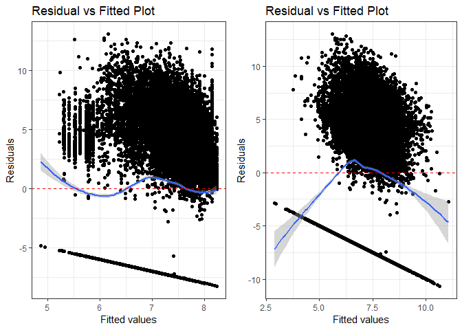

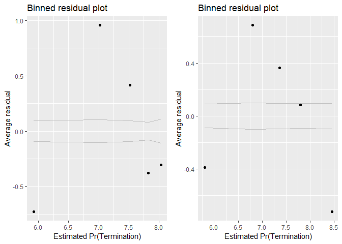

```
## [[1]]
##        model deviance null.deviance difference
## 1 model1_old  2542697       2585789   43092.21
## 2 model1_new  2516861       2585789   68927.87
##
## [[2]]
## cl_US6_avg_sal_lag1Const                  cl_CFTE                  c_pPBSC
##                 1.485861                 1.470224                 1.135510
##                c_pOffPSC               c_pairHist                cl_pairCA
##                 1.719197                 1.445773                 2.175117
```

```r
summary_residual_compare(n_Opt_03C,n_Opt_03D)
```

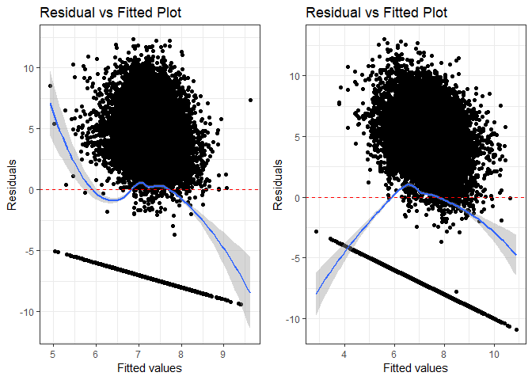

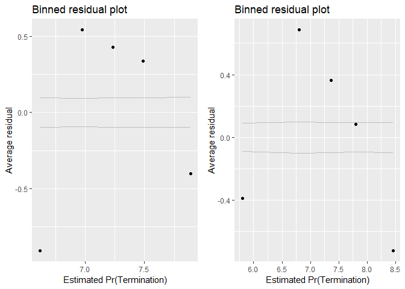

```
## [[1]]
##        model deviance null.deviance difference
## 1 model1_old  2570160       2585789   15629.63
## 2 model1_new  2516861       2585789   68927.87
##
## [[2]]
## cl_US6_avg_sal_lag1Const                  cl_CFTE                  c_pPBSC
##                 1.485861                 1.470224                 1.135510
##                c_pOffPSC               c_pairHist                cl_pairCA
##                 1.719197                 1.445773                 2.175117
```

```r
summary_residual_compare(n_Opt_02D,n_Opt_03D)
```

1. Ceiling breaches: A. Service Complexity: The relationship with average salary gained significance in line with expectation. The result for both average salary and invoice rate matched with expectation.

B. Office Capacity: The relationship with PBSC matched with expectation but with less magnitude. The result for office obligations did not match with expectation.

C. Office-Vendor Relationship: The result for pair history matched with expectation The relationship with contract actions reverse and now align with expectations.

2. Terminations: A. Service Complexity: The reult for average salary did not match with expectation. The result for invoice rate did matach with expectation, only significant (for p-value <0.5), which is still sufficient.

B. Office Capacity: The relationship with PBSC was not significant. The result for office obligations did not match with expectation.

C. Office-Vendor Relationship: The result for pair history matched with expectation once all variables included. The result for contract actions did not match with expectation.

3. Exercised Options: A. Service Complexity: The result for both average salary and invoice rate matached with expectation but with less magnitude.

B. Office Capacity: The result for PBSC didn’t match with expectation. The result for office obligations matched with expectation.

C. Office-Vendor Relationship: The result for pair history lost significance and didn’t match with expectations. The result for contract actions didn’t match with expectation.

## Study Variables Alone

```r
 # !is.na(def_serv$cl_US6_avg_sal_lag1)&
 #  !is.na(def_serv$cl_CFTE)&
 #  !is.na(def_serv$c_pPBSC)&
 #  !is.na(def_serv$c_pOffPSC)&
 #  !is.na(def_serv$c_pairHist)&
 #  !is.na(def_serv$cl_pairCA)&


study_coef_list<-list("(Intercept)"="(Intercept)",
                      "cl_US6_avg_sal_lag1Const"="Log(Det. Ind. Salary)",
                      "cl_CFTE"="Log(Service Invoice Rate)",
                      "c_pPBSC"="Office Perf.-Based %",
                      "c_pOffPSC"="Office Service Exp. %",
                      "c_pairHist"="Paired Years",
                      "cl_pairCA"="Log(Paired Actions)"
)

all_coef_list<-list("(Intercept)"="(Intercept)",
                    "cl_US6_avg_sal_lag1Const"="Log(Det. Ind. Salary)",
                    "cl_CFTE"="Log(Service Invoice Rate)",
                    "c_pPBSC"="Office Perf.-Based %",
                    "c_pOffPSC"="Office Service Exp. %",
                    "c_pairHist"="Paired Years",
                    "cl_pairCA"="Log(Paired Actions)",

                    #Contract Controls

                    "Comp1or51 offer"="Comp=1 offer",
                    "Comp1or52-4 offers"="Comp=2-4 offers",
                    "Comp1or55+ offers"="Comp=5+ offers",

                    "CompOffr1 offer"="Comp=1 offer",
                    "CompOffr2 offers"="Comp=2 offers",
                    "CompOffr3-4 offers"="Comp=3-4 offers",
                    "CompOffr5+ offers"="Comp=5+ offers",

                    "cl_Ceil"="Log(Init. Ceiling)",
                    "capped_cl_Days"="Log(Init. Days)",
                    "VehS-IDC"="Vehicle=S-IDC",
                    "VehM-IDC"="Vehicle=M-IDC",
                    "VehFSS/GWAC"="Vehicle=FSS/GWAC",
                    "VehBPA/BOA"="Vehicle=BPA/BOA",
                    "PricingUCAFFP"="Pricing=FFP",
                    "PricingUCAOther FP"="Pricing=Other FP",
                    "PricingUCAIncentive"="Pricing=Incentive Fee",
                    "PricingUCACombination or Other"="Pricing=Combination or Other",
                    "PricingUCAOther CB"="Pricing=Other CB",
                    "PricingUCAT&M/LH/FPLOE"="Pricing=T&M/LH/FP:LoE",
                    "PricingUCAUCA"="Pricing=UCA",

                    "PricingFeeOther FP"="Pricing=Other FP",
                    "PricingFeeIncentive"="Pricing=Incentive Fee",
                    "PricingFeeCombination or Other"="Pricing=Combination or Other",
                    "PricingFeeOther CB"="Pricing=Other CB",
                    "PricingFeeT&M/LH/FPLOE"="Pricing=T&M/LH/FP:LoE",
                    "b_UCA"="UCA",
                    "CrisisARRA"="Crisis=ARRA",
                    "CrisisDis"="Crisis=Disaster",
                    "CrisisOCO"="Crisis=OCO",
                    "b_Intl"="Performed Abroad",

                    #NAICS
                    "cl_def3_HHI_lag1"="Log(Subsector HHI)",
                    "cl_def6_HHI_lag1"="Log(Det. Ind. HHI)",
                    "cl_def3_ratio_lag1"="Log(Subsector Ratio)",
                    "cl_def6_obl_lag1"="Log(Det. Ind. DoD Obl.)",
                    "cl_def6_ratio_lag1"="Log(Det. Ind. Ratio)",
                    #Office
                    "c_pMarket"="Percent Market",
                    "cl_OffVol"="Office Volume",
                    "cl_office_naics_hhi_k"="Office Concentration",


                    #interations
                    # # "cl_def6_HHI_lag1:capped_cl_Days"="Log(Det. Ind. HHI):Log(Init. Days)",
                    # "cl_def6_HHI_lag1:cl_def6_obl_lag1"="Log(Det. Ind. HHI):Log(Det. Ind. DoD Obl.)",
                    # # "cl_def3_HHI_lag1:cl_def3_ratio_lag1"="Log(Subsector HHI):Log(Subsector Ratio)"),
                    "cl_def6_HHI_lag1:b_UCA"="Log(Det. Ind. HHI):UCA",
                    # "cl_Ceil:b_UCA"="Log(Init. Ceiling):UCA",
                    # "CompOffr1 offer:b_UCA"="Comp=1 offer:UCA",
                    # "CompOffr2 offers:b_UCA"="Comp=2 offers:UCA",
                    # "CompOffr3-4 offers:b_UCA"="Comp=3-4 offers:UCA",
                    # "CompOffr5+ offers:b_UCA"="Comp=5+ offers:UCA"
                    "VehS-IDC:b_Intl"="Vehicle=S-IDC:Performed Abroad",
                    "VehM-IDC:b_Intl"="Vehicle=M-IDC:Performed Abroad",
                    "VehFSS/GWAC:b_Intl"="Vehicle=FSS/GWAC:Performed Abroad",
                    "VehBPA/BOA:b_Intl"="Vehicle=BPA/BOA:Performed Abroad",
                    "cl_US6_avg_sal_lag1:PricingFeeOther FP"="Pricing=Other FP:Log(Det. Ind. U.S. Avg. Salary)",
                    "cl_US6_avg_sal_lag1:PricingFeeIncentive"="Pricing=Incentive Fee:Log(Det. Ind. U.S. Avg. Salary)",
                    "cl_US6_avg_sal_lag1:PricingFeeCombination or Other"="Pricing=Comb./or Other:Log(Det. Ind. U.S. Avg. Salary)",
                    "cl_US6_avg_sal_lag1:PricingFeeOther CB"="Pricing=Other CB:Log(Det. Ind. U.S. Avg. Salary)",
                    "cl_US6_avg_sal_lag1:PricingFeeT&M/LH/FPLOE"="Pricing=T&M/LH/FP:LoE:Log(Det. Ind. U.S. Avg. Salary)"
)



#Exercised Options Absolute
  stargazer::stargazer(n_Opt_01A,n_Opt_01B,n_Opt_02A,n_Opt_02B,n_Opt_03A,n_Opt_03B,n_Opt_03D,
                       type="text",
                       digits=2)
```

```
##
## ============================================================================================================
##                                                          Dependent variable:
##                          -----------------------------------------------------------------------------------
##                                                             ln_OptGrowth
##                              (1)         (2)         (3)         (4)         (5)         (6)         (7)
## ------------------------------------------------------------------------------------------------------------
## cl_US6_avg_sal_lag1Const   0.19***                                                                 0.82***
##                            (0.04)                                                                  (0.05)
##
## cl_CFTE                               -0.52***                                                    -0.73***
##                                        (0.05)                                                      (0.06)
##
## c_pPBSC                                           -0.57***                                        -0.35***
##                                                    (0.05)                                          (0.05)
##
## c_pOffPSC                                                     -0.36***                             1.31***
##                                                                (0.05)                              (0.07)
##
## c_pairHist                                                                -0.61***                 0.34***
##                                                                            (0.04)                  (0.05)
##
## cl_pairCA                                                                             -1.35***    -2.14***
##                                                                                        (0.04)      (0.06)
##
## Constant                   7.23***     7.25***     7.25***     7.23***     7.19***     7.08***     7.01***
##                            (0.02)      (0.02)      (0.02)      (0.02)      (0.02)      (0.02)      (0.02)
##
## ------------------------------------------------------------------------------------------------------------
## Observations               74,162      74,162      74,162      74,162      74,162      74,162      74,162
## Log Likelihood           -236,915.50 -236,866.00 -236,852.70 -236,901.90 -236,816.30 -236,315.40 -235,924.90
## Akaike Inf. Crit.        473,834.90  473,736.00  473,709.30  473,807.70  473,636.60  472,634.80  471,863.80
## ============================================================================================================
## Note:                                                                            *p<0.1; **p<0.05; ***p<0.01
```

```r
texreg::htmlreg(list(n_Opt_01A,n_Opt_01B,n_Opt_02A,n_Opt_02B,n_Opt_03A,n_Opt_03B,n_Opt_03D),file="..//Output//n_Opt_Model.html",
                single.row = TRUE,
                # custom.model.name=c("Ceiling Breaches"),
                stars=c(0.1,0.05,0.01,0.001),
                groups = list(
                              "Services Complexity" = 2:3,
                              "Office Capacity" =4:5,
                              "Past Relationship"=6:7
                              ),
                custom.coef.map=all_coef_list,
                bold=0.05,
                custom.note="%stars. Numerical inputs are rescaled.",
                caption="Table 6: Logit Bivariate Look at Study Variables and Ceiling Breaches",
                caption.above=TRUE)
```

```
## The table was written to the file '..//Output//n_Opt_Model.html'.
```

```r
#Exercised Options Percentage
stargazer::stargazer(p_Opt_01A,p_Opt_01B,p_Opt_02A,p_Opt_02B,p_Opt_03A,p_Opt_03B,p_Opt_03D,
                       type="text",
                       digits=2)
```

```
##
## =====================================================================================================
##                                                      Dependent variable:
##                          ----------------------------------------------------------------------------
##                                                          lp_OptGrowth
##                             (1)        (2)        (3)        (4)        (5)        (6)        (7)
## -----------------------------------------------------------------------------------------------------
## cl_US6_avg_sal_lag1Const  -0.07***                                                          -0.02***
##                           (0.005)                                                            (0.01)
##
## cl_CFTE                              -0.14***                                               -0.13***
##                                       (0.01)                                                 (0.01)
##
## c_pPBSC                                         -0.05***                                    -0.03***
##                                                  (0.01)                                      (0.01)
##
## c_pOffPSC                                                  0.12***                          0.28***
##                                                             (0.01)                           (0.01)
##
## c_pairHist                                                            -0.04***               -0.001
##                                                                       (0.005)                (0.01)
##
## cl_pairCA                                                                        -0.04***   -0.13***
##                                                                                  (0.005)     (0.01)
##
## Constant                  0.65***    0.65***    0.65***    0.65***    0.64***    0.64***    0.64***
##                           (0.003)    (0.003)    (0.003)    (0.003)    (0.003)    (0.003)    (0.003)
##
## -----------------------------------------------------------------------------------------------------
## Observations               74,162     74,162     74,162     74,162     74,162     74,162     74,162
## Log Likelihood           -77,199.78 -77,007.63 -77,294.40 -77,130.56 -77,288.54 -77,294.15 -76,354.49
## Akaike Inf. Crit.        154,403.60 154,019.30 154,592.80 154,265.10 154,581.10 154,592.30 152,723.00
## =====================================================================================================
## Note:                                                                     *p<0.1; **p<0.05; ***p<0.01
```

```r
texreg::htmlreg(list(p_Opt_01A,p_Opt_01B,p_Opt_02A,p_Opt_02B,p_Opt_03A,p_Opt_03B,p_Opt_03D),file="..//Output//p_Opt_Model.html",
                single.row = TRUE,
                # custom.model.name=c("Ceiling Breaches"),
                stars=c(0.1,0.05,0.01,0.001),
                groups = list(
                              "Services Complexity" = 2:3,
                              "Office Capacity" =4:5,
                              "Past Relationship"=6:7
                              ),
                custom.coef.map=all_coef_list,
                bold=0.05,
                custom.note="%stars. Numerical inputs are rescaled.",
                caption="Table 8: Regression Bivariate Look at Study Variables and Log(Options Growth)",
                caption.above=TRUE)
```

```
## The table was written to the file '..//Output//p_Opt_Model.html'.
```

# Controls

## Contract-Level Controls

### Scope Variables

#### 04A: Cost Ceiling

Expectation: Initial Ceiling size positively estimates increasing probability of ceiling breaches and terminations and negatively estimates the option growth. Terminations and ceiling breaches simply comes down to large being associated with higher risk, while for option growth size imply makes it harder to grow proportionally.

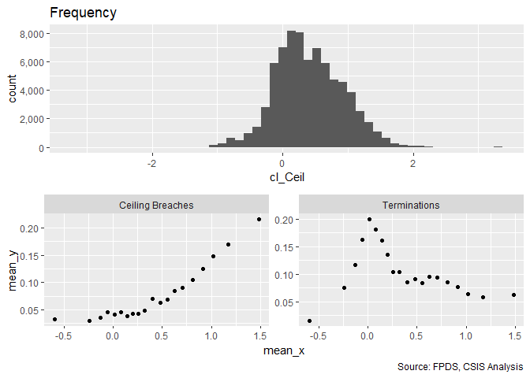

```r
#Frequency Plot for unlogged ceiling
# freq_continuous_cbre_plot(serv_opt,"UnmodifiedContractBaseAndAllOptionsValue.OMB20_GDP18",
#                bins=1000)
# freq_continuous_cbre_plot(subset(serv_opt,UnmodifiedContractBaseAndAllOptionsValue.OMB20_GDP18<100000000),
#                "UnmodifiedContractBaseAndAllOptionsValue.OMB20_GDP18",
#                bins=1000)

summary_continuous_plot(serv_opt,"cl_Ceil",bins=50)
```

```r
summary(serv_opt$cl_Ceil)
```

```
##     Min.  1st Qu.   Median     Mean  3rd Qu.     Max.
## -3.23331  0.05014  0.36269  0.40879  0.75467  3.24200
```

```r
str(serv_opt)
```

[output not shown]

[output cut: 96 more lines]

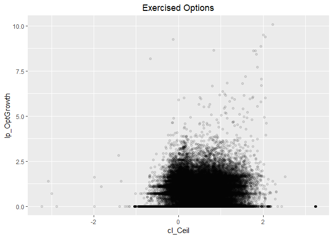

```r
#Scatter Plot
ggplot(serv_opt, aes(x=cl_Ceil, y=lp_OptGrowth)) + geom_point(alpha = 0.1) + ggtitle('Exercised Options') + theme(plot.title = element_text(hjust = 0.5))
```

```r
#Model
n_Opt_04A <- glm (data=serv_opt,
                 ln_OptGrowth ~ cl_Ceil)
display(n_Opt_04A)
```

```
## glm(formula = ln_OptGrowth ~ cl_Ceil, data = serv_opt)
##             coef.est coef.se
## (Intercept) 5.69     0.03
## cl_Ceil     3.80     0.04
## ---
##   n = 74162, k = 2
##   residual deviance = 2310775.1, null deviance = 2585789.3 (difference = 275014.2)
##   overdispersion parameter = 31.2
##   residual sd is sqrt(overdispersion) = 5.58
```

```r
p_Opt_04A <- glm(data=serv_opt,
                        lp_OptGrowth ~ cl_Ceil)

display(p_Opt_04A)
```

```
## glm(formula = lp_OptGrowth ~ cl_Ceil, data = serv_opt)
##             coef.est coef.se
## (Intercept) 0.59     0.00
## cl_Ceil     0.13     0.00
## ---
##   n = 74162, k = 2
##   residual deviance = 34617.0, null deviance = 34944.5 (difference = 327.5)
##   overdispersion parameter = 0.5
##   residual sd is sqrt(overdispersion) = 0.68
```

```r
#Plot residuals versus fitted
stargazer::stargazer(n_Opt_03D,n_Opt_04A,

                       p_Opt_03D,p_Opt_04A,
                       type="text",
                       digits=2)
```

```
##
## ======================================================================
##                                       Dependent variable:
##                          ---------------------------------------------
##                               ln_OptGrowth           lp_OptGrowth
##                              (1)         (2)        (3)        (4)
## ----------------------------------------------------------------------
## cl_US6_avg_sal_lag1Const   0.82***                -0.02***
##                            (0.05)                  (0.01)
##
## cl_CFTE                   -0.73***                -0.13***
##                            (0.06)                  (0.01)
##
## c_pPBSC                   -0.35***                -0.03***
##                            (0.05)                  (0.01)
##
## c_pOffPSC                  1.31***                0.28***
##                            (0.07)                  (0.01)
##
## c_pairHist                 0.34***                 -0.001
##                            (0.05)                  (0.01)
##
## cl_pairCA                 -2.14***                -0.13***
##                            (0.06)                  (0.01)
##
## cl_Ceil                                3.80***               0.13***
##                                        (0.04)                (0.005)
##
## Constant                   7.01***     5.69***    0.64***    0.59***
##                            (0.02)      (0.03)     (0.003)    (0.003)
##
## ----------------------------------------------------------------------
## Observations               74,162      74,162      74,162     74,162
## Log Likelihood           -235,924.90 -232,757.10 -76,354.49 -76,980.03
## Akaike Inf. Crit.        471,863.80  465,518.20  152,723.00 153,964.10
## ======================================================================
## Note:                                      *p<0.1; **p<0.05; ***p<0.01
```

```r
#summary_residual_compare(n_Opt_03D,n_Opt_04A, skip_vif = TRUE)
```

Contract ceiling has a significant relationship, though the residuals show a possible non-linear patterns. This is most remarkable in the positive centered values between 0 and 1. This may be driven by a missing value and is worth watching. Expectations upheld for ceiling breaches and terminations. Weak expectations for options growth were countered.

#### 04B: Maximum Duration

Expectation: Greater maximum duration will positively estimate the probability ceiling of breaches and terminations. Greater growth for options is also expected, because year-on-year options may be more of a default, though the scatter plot seems to go the other way.

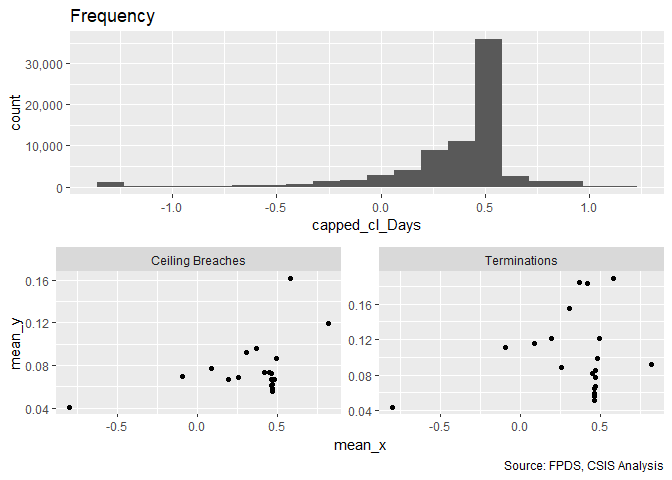

```r
#Frequency Plot for max duration
# freq_continuous_cbre_plot(serv_opt,"UnmodifiedDays",
#                bins=1000)

summary_continuous_plot(serv_opt,"capped_cl_Days")
```

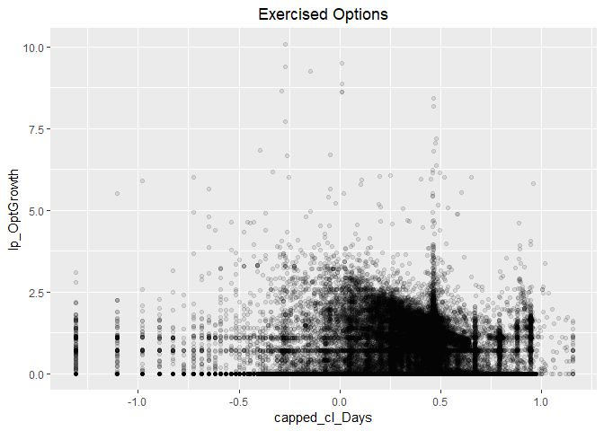

```r
#Scatter Plot
ggplot(serv_opt, aes(x=capped_cl_Days, y=lp_OptGrowth)) + geom_point(alpha = 0.1) + ggtitle('Exercised Options') + theme(plot.title = element_text(hjust = 0.5))
```

```r
#Model
n_Opt_04B <- glm (data=serv_opt,
                 ln_OptGrowth ~ capped_cl_Days)
display(n_Opt_04B)
```

```
## glm(formula = ln_OptGrowth ~ capped_cl_Days, data = serv_opt)
##                coef.est coef.se
## (Intercept)    6.08     0.03
## capped_cl_Days 3.42     0.06
## ---
##   n = 74162, k = 2
##   residual deviance = 2488923.5, null deviance = 2585789.3 (difference = 96865.8)
##   overdispersion parameter = 33.6
##   residual sd is sqrt(overdispersion) = 5.79
```

```r
p_Opt_04B <- glm(data=serv_opt,
                        lp_OptGrowth ~ capped_cl_Days)

display(p_Opt_04B)
```

```
## glm(formula = lp_OptGrowth ~ capped_cl_Days, data = serv_opt)
##                coef.est coef.se
## (Intercept)    0.59     0.00
## capped_cl_Days 0.17     0.01
## ---
##   n = 74162, k = 2
##   residual deviance = 34709.6, null deviance = 34944.5 (difference = 234.9)
##   overdispersion parameter = 0.5
##   residual sd is sqrt(overdispersion) = 0.68
```

```r
#Plot residuals versus fitted
stargazer::stargazer(n_Opt_03D,n_Opt_04A,n_Opt_04B,

                       p_Opt_03D,p_Opt_04A,p_Opt_04B,
                       type="text",
                       digits=2)
```

```
##
## =============================================================================================
##                                                  Dependent variable:
##                          --------------------------------------------------------------------
##                                     ln_OptGrowth                       lp_OptGrowth
##                              (1)         (2)         (3)        (4)        (5)        (6)
## ---------------------------------------------------------------------------------------------
## cl_US6_avg_sal_lag1Const   0.82***                            -0.02***
##                            (0.05)                              (0.01)
##
## cl_CFTE                   -0.73***                            -0.13***
##                            (0.06)                              (0.01)
##
## c_pPBSC                   -0.35***                            -0.03***
##                            (0.05)                              (0.01)
##
## c_pOffPSC                  1.31***                            0.28***
##                            (0.07)                              (0.01)
##
## c_pairHist                 0.34***                             -0.001
##                            (0.05)                              (0.01)
##
## cl_pairCA                 -2.14***                            -0.13***
##                            (0.06)                              (0.01)
##
## cl_Ceil                                3.80***                           0.13***
##                                        (0.04)                            (0.005)
##
## capped_cl_Days                                     3.42***                          0.17***
##                                                    (0.06)                            (0.01)
##
## Constant                   7.01***     5.69***     6.08***    0.64***    0.59***    0.59***
##                            (0.02)      (0.03)      (0.03)     (0.003)    (0.003)    (0.004)
##
## ---------------------------------------------------------------------------------------------
## Observations               74,162      74,162      74,162      74,162     74,162     74,162
## Log Likelihood           -235,924.90 -232,757.10 -235,511.00 -76,354.49 -76,980.03 -77,079.10
## Akaike Inf. Crit.        471,863.80  465,518.20  471,026.00  152,723.00 153,964.10 154,162.20
## =============================================================================================
## Note:                                                             *p<0.1; **p<0.05; ***p<0.01
```

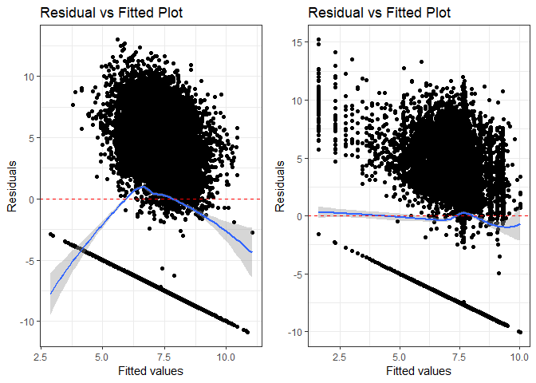

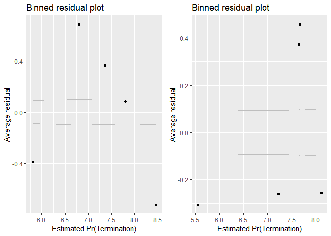

```r
summary_residual_compare(n_Opt_03D,n_Opt_04B, skip_vif = TRUE)
```

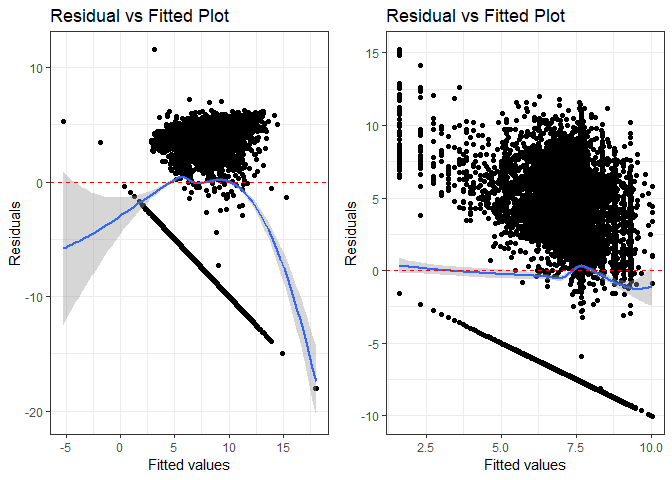

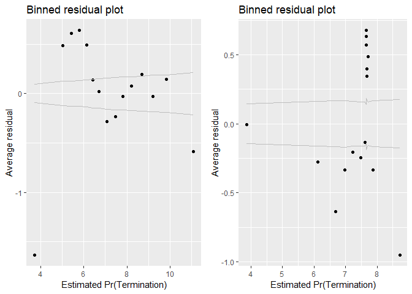

```r
summary_residual_compare(n_Opt_04A,n_Opt_04B, skip_vif = TRUE)
```

All expections were upheld.

#### 04C: Both Scope variables

```r
#Model
n_Opt_04C <- glm (data=serv_opt,
                 ln_OptGrowth ~ cl_Ceil + capped_cl_Days)
display(n_Opt_04C)
```

```
## glm(formula = ln_OptGrowth ~ cl_Ceil + capped_cl_Days, data = serv_opt)
##                coef.est coef.se
## (Intercept)    4.88     0.03
## cl_Ceil        3.55     0.04
## capped_cl_Days 2.67     0.06
## ---
##   n = 74162, k = 3
##   residual deviance = 2253067.0, null deviance = 2585789.3 (difference = 332722.3)
##   overdispersion parameter = 30.4
##   residual sd is sqrt(overdispersion) = 5.51
```

```r
p_Opt_04C <- glm(data=serv_opt,
                        lp_OptGrowth ~cl_Ceil + capped_cl_Days)

display(p_Opt_04C)
```

```
## glm(formula = lp_OptGrowth ~ cl_Ceil + capped_cl_Days, data = serv_opt)
##                coef.est coef.se
## (Intercept)    0.55     0.00
## cl_Ceil        0.12     0.00
## capped_cl_Days 0.14     0.01
## ---
##   n = 74162, k = 3
##   residual deviance = 34450.0, null deviance = 34944.5 (difference = 494.5)
##   overdispersion parameter = 0.5
##   residual sd is sqrt(overdispersion) = 0.68
```

```r
#Plot residuals versus fitted
stargazer::stargazer(n_Opt_03D,n_Opt_04A,n_Opt_04B,n_Opt_04C,

                       p_Opt_03D,p_Opt_04A,p_Opt_04B,p_Opt_04C,
                       type="text",
                       digits=2)
```

```
##
## ====================================================================================================================
##                                                              Dependent variable:
##                          -------------------------------------------------------------------------------------------
##                                           ln_OptGrowth                                  lp_OptGrowth
##                              (1)         (2)         (3)         (4)        (5)        (6)        (7)        (8)
## --------------------------------------------------------------------------------------------------------------------
## cl_US6_avg_sal_lag1Const   0.82***                                        -0.02***
##                            (0.05)                                          (0.01)
##
## cl_CFTE                   -0.73***                                        -0.13***
##                            (0.06)                                          (0.01)
##
## c_pPBSC                   -0.35***                                        -0.03***
##                            (0.05)                                          (0.01)
##
## c_pOffPSC                  1.31***                                        0.28***
##                            (0.07)                                          (0.01)
##
## c_pairHist                 0.34***                                         -0.001
##                            (0.05)                                          (0.01)
##
## cl_pairCA                 -2.14***                                        -0.13***
##                            (0.06)                                          (0.01)
##
## cl_Ceil                                3.80***                 3.55***               0.13***               0.12***
##                                        (0.04)                  (0.04)                (0.005)               (0.005)
##
## capped_cl_Days                                     3.42***     2.67***                          0.17***    0.14***
##                                                    (0.06)      (0.06)                            (0.01)     (0.01)
##
## Constant                   7.01***     5.69***     6.08***     4.88***    0.64***    0.59***    0.59***    0.55***
##                            (0.02)      (0.03)      (0.03)      (0.03)     (0.003)    (0.003)    (0.004)    (0.004)
##
## --------------------------------------------------------------------------------------------------------------------
## Observations               74,162      74,162      74,162      74,162      74,162     74,162     74,162     74,162
## Log Likelihood           -235,924.90 -232,757.10 -235,511.00 -231,819.30 -76,354.49 -76,980.03 -77,079.10 -76,800.73
## Akaike Inf. Crit.        471,863.80  465,518.20  471,026.00  463,644.60  152,723.00 153,964.10 154,162.20 153,607.50
## ====================================================================================================================
## Note:                                                                                    *p<0.1; **p<0.05; ***p<0.01
```

```r
#summary_residual_compare(n_Opt_03D,n_Opt_04C)
#summary_residual_compare(n_Opt_04A,n_Opt_04C)
#summary_residual_compare(n_Opt_04B,n_Opt_04C)
```

Days loses significance for ceiling breaches. Ceiling has a smaller coefficient for terminations. Otherwise largely unchanged.

#### 04D: Cumulative Model

```r
#Model
n_Opt_04D <- glm (data=serv_opt,
                 ln_OptGrowth ~  cl_US6_avg_sal_lag1Const +
                   cl_CFTE+ c_pPBSC+c_pOffPSC+
                 c_pairHist+cl_pairCA +
                   cl_Ceil + capped_cl_Days)
glmer_examine(n_Opt_04D)
```

```
## cl_US6_avg_sal_lag1Const                  cl_CFTE                  c_pPBSC
##                 1.547595                 1.470315                 1.175353
##                c_pOffPSC               c_pairHist                cl_pairCA
##                 1.720683                 1.451477                 2.259309
##                  cl_Ceil           capped_cl_Days
##                 1.101473                 1.066936
```

```r
p_Opt_04D <- glm(data=serv_opt,
                        lp_OptGrowth ~  cl_US6_avg_sal_lag1Const +
                   cl_CFTE+ c_pPBSC+c_pOffPSC+
                 c_pairHist+cl_pairCA+
                 cl_Ceil + capped_cl_Days)

glmer_examine(p_Opt_04D)
```

```
## cl_US6_avg_sal_lag1Const                  cl_CFTE                  c_pPBSC
##                 1.547595                 1.470315                 1.175353
##                c_pOffPSC               c_pairHist                cl_pairCA
##                 1.720683                 1.451477                 2.259309
##                  cl_Ceil           capped_cl_Days
##                 1.101473                 1.066936
```

```r
#Plot residuals versus fitted

stargazer::stargazer(n_Opt_03D,n_Opt_04C,n_Opt_04D,

                       p_Opt_03D,p_Opt_04C,p_Opt_04D,
                       type="text",
                       digits=2)
```

```
##
## =============================================================================================
##                                                  Dependent variable:
##                          --------------------------------------------------------------------
##                                     ln_OptGrowth                       lp_OptGrowth
##                              (1)         (2)         (3)        (4)        (5)        (6)
## ---------------------------------------------------------------------------------------------
## cl_US6_avg_sal_lag1Const   0.82***                  -0.06     -0.02***              -0.06***
##                            (0.05)                  (0.05)      (0.01)                (0.01)
##
## cl_CFTE                   -0.73***                -0.77***    -0.13***              -0.13***
##                            (0.06)                  (0.05)      (0.01)                (0.01)
##
## c_pPBSC                   -0.35***                 0.21***    -0.03***              -0.02***
##                            (0.05)                  (0.05)      (0.01)                (0.01)
##
## c_pOffPSC                  1.31***                 1.13***    0.28***               0.27***
##                            (0.07)                  (0.06)      (0.01)                (0.01)
##
## c_pairHist                 0.34***                 0.25***     -0.001                -0.01
##                            (0.05)                  (0.05)      (0.01)                (0.01)
##
## cl_pairCA                 -2.14***                -1.34***    -0.13***              -0.09***
##                            (0.06)                  (0.05)      (0.01)                (0.01)
##
## cl_Ceil                                3.55***     3.58***               0.12***    0.13***
##                                        (0.04)      (0.04)                (0.005)     (0.01)
##
## capped_cl_Days                         2.67***     2.42***               0.14***    0.15***
##                                        (0.06)      (0.06)                 (0.01)     (0.01)
##
## Constant                   7.01***     4.88***     4.86***    0.64***    0.55***    0.54***
##                            (0.02)      (0.03)      (0.03)     (0.003)    (0.004)    (0.004)
##
## ---------------------------------------------------------------------------------------------
## Observations               74,162      74,162      74,162      74,162     74,162     74,162
## Log Likelihood           -235,924.90 -231,819.30 -231,287.00 -76,354.49 -76,800.73 -75,747.51
## Akaike Inf. Crit.        471,863.80  463,644.60  462,592.00  152,723.00 153,607.50 151,513.00
## =============================================================================================
## Note:                                                             *p<0.1; **p<0.05; ***p<0.01
```

```r
#summary_residual_compare(n_Opt_03D,n_Opt_04D)
#summary_residual_compare(n_Opt_04C,n_Opt_04D)
```

Salary no longer matches expectations for ceiling breaches. Invoice rate is no longer significant for terminations.

### Competition

#### 05A: No Competition / 1 / 2-4 / 5+ Offers

Expectations No Competition (Baseline) + - - 1 Offer + - - 2-4 Offers - + + 5+ Offers - + -

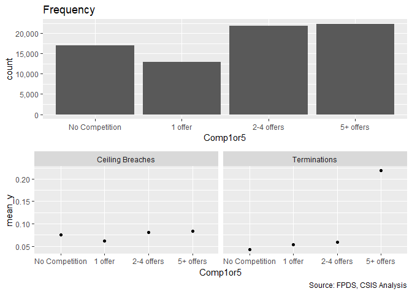

```
## [[1]]
##
## No Competition        1 offer     2-4 offers      5+ offers
##          17031          12887          21862          22382
##
## [[2]]
##
##                   None Ceiling Breach
##   No Competition 15737           1294
##   1 offer        12092            795
##   2-4 offers     20099           1763
##   5+ offers      20515           1867
##
## [[3]]
##
##                      0     1
##   No Competition 16307   724
##   1 offer        12193   694
##   2-4 offers     20582  1280
##   5+ offers      17480  4902
```

```r
summary_discrete_plot(serv_opt,"Comp1or5")
```

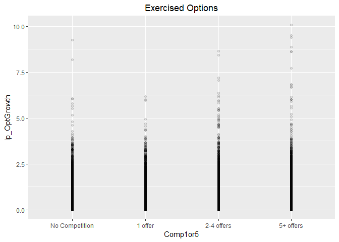

```r
#Scatter Plot
ggplot(serv_opt, aes(x=Comp1or5, y=lp_OptGrowth)) + geom_point(alpha = 0.1) + ggtitle('Exercised Options') + theme(plot.title = element_text(hjust = 0.5))
```

```r
#Model
n_Opt_05A <- glm (data=serv_opt,
                 ln_OptGrowth ~ Comp1or5)
display(n_Opt_05A)
```

```
## glm(formula = ln_OptGrowth ~ Comp1or5, data = serv_opt)
##                    coef.est coef.se
## (Intercept)         7.83     0.05
## Comp1or51 offer    -1.14     0.07
## Comp1or52-4 offers -0.38     0.06
## Comp1or55+ offers  -0.92     0.06
## ---
##   n = 74162, k = 4
##   residual deviance = 2572500.8, null deviance = 2585789.3 (difference = 13288.5)
##   overdispersion parameter = 34.7
##   residual sd is sqrt(overdispersion) = 5.89
```

```r
p_Opt_05A <- glm(data=serv_opt,
                        lp_OptGrowth ~ Comp1or5)

display(p_Opt_05A)
```

```
## glm(formula = lp_OptGrowth ~ Comp1or5, data = serv_opt)
##                    coef.est coef.se
## (Intercept)         0.64     0.01
## Comp1or51 offer    -0.03     0.01
## Comp1or52-4 offers  0.00     0.01
## Comp1or55+ offers   0.04     0.01
## ---
##   n = 74162, k = 4
##   residual deviance = 34900.9, null deviance = 34944.5 (difference = 43.6)
##   overdispersion parameter = 0.5
##   residual sd is sqrt(overdispersion) = 0.69
```

```r
#Plot residuals versus fitted
stargazer::stargazer(n_Opt_04D,n_Opt_05A,

                       p_Opt_04D,p_Opt_05A,
                       type="text",
                       digits=2)
```

```
##
## ======================================================================
##                                       Dependent variable:
##                          ---------------------------------------------
##                               ln_OptGrowth           lp_OptGrowth
##                              (1)         (2)        (3)        (4)
## ----------------------------------------------------------------------
## cl_US6_avg_sal_lag1Const    -0.06                 -0.06***
##                            (0.05)                  (0.01)
##
## cl_CFTE                   -0.77***                -0.13***
##                            (0.05)                  (0.01)
##
## c_pPBSC                    0.21***                -0.02***
##                            (0.05)                  (0.01)
##
## c_pOffPSC                  1.13***                0.27***
##                            (0.06)                  (0.01)
##
## c_pairHist                 0.25***                 -0.01
##                            (0.05)                  (0.01)
##
## cl_pairCA                 -1.34***                -0.09***
##                            (0.05)                  (0.01)
##
## cl_Ceil                    3.58***                0.13***
##                            (0.04)                  (0.01)
##
## capped_cl_Days             2.42***                0.15***
##                            (0.06)                  (0.01)
##
## Comp1or51 offer                       -1.14***               -0.03***
##                                        (0.07)                 (0.01)
##
## Comp1or52-4 offers                    -0.38***                0.002
##                                        (0.06)                 (0.01)
##
## Comp1or55+ offers                     -0.92***               0.04***
##                                        (0.06)                 (0.01)
##
## Constant                   4.86***     7.83***    0.54***    0.64***
##                            (0.03)      (0.05)     (0.004)     (0.01)
##
## ----------------------------------------------------------------------
## Observations               74,162      74,162      74,162     74,162
## Log Likelihood           -231,287.00 -236,735.70 -75,747.51 -77,282.92
## Akaike Inf. Crit.        462,592.00  473,479.40  151,513.00 154,573.90
## ======================================================================
## Note:                                      *p<0.1; **p<0.05; ***p<0.01
```

#### 05B: Cumulative Model

```r
#Model
n_Opt_05B <- glm (data=serv_opt,
                 ln_OptGrowth ~  cl_US6_avg_sal_lag1Const +
                   cl_CFTE+ c_pPBSC+c_pOffPSC+
                 c_pairHist+cl_pairCA +
                   cl_Ceil + capped_cl_Days+
                   Comp1or5)
glmer_examine(n_Opt_05B)
```

```
##                              GVIF Df GVIF^(1/(2*Df))
## cl_US6_avg_sal_lag1Const 1.553771  1        1.246504
## cl_CFTE                  1.472521  1        1.213475
## c_pPBSC                  1.196281  1        1.093746
## c_pOffPSC                1.757626  1        1.325755
## c_pairHist               1.494454  1        1.222479
## cl_pairCA                2.405111  1        1.550842
## cl_Ceil                  1.111130  1        1.054102
## capped_cl_Days           1.094821  1        1.046337
## Comp1or5                 1.288884  3        1.043203
```

```r
p_Opt_05B <- glm(data=serv_opt,
                        lp_OptGrowth ~  cl_US6_avg_sal_lag1Const +
                   cl_CFTE+ c_pPBSC+c_pOffPSC+
                 c_pairHist+cl_pairCA+
                 cl_Ceil + capped_cl_Days+
                 Comp1or5)

glmer_examine(p_Opt_05B)
```

```
##                              GVIF Df GVIF^(1/(2*Df))
## cl_US6_avg_sal_lag1Const 1.553771  1        1.246504
## cl_CFTE                  1.472521  1        1.213475
## c_pPBSC                  1.196281  1        1.093746
## c_pOffPSC                1.757626  1        1.325755
## c_pairHist               1.494454  1        1.222479
## cl_pairCA                2.405111  1        1.550842
## cl_Ceil                  1.111130  1        1.054102
## capped_cl_Days           1.094821  1        1.046337
## Comp1or5                 1.288884  3        1.043203
```

```r
#Plot residuals versus fitted

stargazer::stargazer(n_Opt_04D,n_Opt_05A,n_Opt_05B,

                       p_Opt_04D,p_Opt_05A,p_Opt_05B,
                       type="text",
                       digits=2)
```

```
##
## =============================================================================================
##                                                  Dependent variable:
##                          --------------------------------------------------------------------
##                                     ln_OptGrowth                       lp_OptGrowth
##                              (1)         (2)         (3)        (4)        (5)        (6)
## ---------------------------------------------------------------------------------------------
## cl_US6_avg_sal_lag1Const    -0.06                   -0.07     -0.06***              -0.06***
##                            (0.05)                  (0.05)      (0.01)                (0.01)
##
## cl_CFTE                   -0.77***                -0.78***    -0.13***              -0.14***
##                            (0.05)                  (0.05)      (0.01)                (0.01)
##
## c_pPBSC                    0.21***                 0.18***    -0.02***              -0.02***
##                            (0.05)                  (0.05)      (0.01)                (0.01)
##
## c_pOffPSC                  1.13***                 1.12***    0.27***               0.26***
##                            (0.06)                  (0.06)      (0.01)                (0.01)
##
## c_pairHist                 0.25***                 0.27***     -0.01                -0.0001
##                            (0.05)                  (0.05)      (0.01)                (0.01)
##
## cl_pairCA                 -1.34***                -1.34***    -0.09***              -0.10***
##                            (0.05)                  (0.06)      (0.01)                (0.01)
##
## cl_Ceil                    3.58***                 3.57***    0.13***               0.14***
##                            (0.04)                  (0.04)      (0.01)                (0.01)
##
## capped_cl_Days             2.42***                 2.39***    0.15***               0.14***
##                            (0.06)                  (0.06)      (0.01)                (0.01)
##
## Comp1or51 offer                       -1.14***    -0.36***               -0.03***    -0.01
##                                        (0.07)      (0.06)                 (0.01)     (0.01)
##
## Comp1or52-4 offers                    -0.38***    -0.22***                0.002      -0.01*
##                                        (0.06)      (0.06)                 (0.01)     (0.01)
##
## Comp1or55+ offers                     -0.92***     -0.12**               0.04***    0.04***
##                                        (0.06)      (0.06)                 (0.01)     (0.01)
##
## Constant                   4.86***     7.83***     5.04***    0.54***    0.64***    0.53***
##                            (0.03)      (0.05)      (0.05)     (0.004)     (0.01)     (0.01)
##
## ---------------------------------------------------------------------------------------------
## Observations               74,162      74,162      74,162      74,162     74,162     74,162
## Log Likelihood           -231,287.00 -236,735.70 -231,270.20 -75,747.51 -77,282.92 -75,715.88
## Akaike Inf. Crit.        462,592.00  473,479.40  462,564.30  151,513.00 154,573.90 151,455.80
## =============================================================================================
## Note:                                                             *p<0.1; **p<0.05; ***p<0.01
```

```r
#summary_residual_compare(n_Opt_04D,n_Opt_05B)
```

Minimal effect on study variables. 2-4 offers for terminations is not longer significant, it’s really 5+ that boosts the risks. But for exercised options, 5+ leads to more options while fewer having negative relationship with 2-4 offers, but only significant with p-value < 0.1

### Contract Vehicle

#### 06A: Def/Pur; S-IDC; M-IDC; FSS-GWAC; BPA-BOA.

Old text: Expectation: Indefinite delivery vehicles, means that the government has an existing relationship with the vendor and administration is easier. The downside is that the government may be locked into the vendor, although exit does not necessarily require outright termination, instead the government may simply cease to use a vehicle. Taken together, across the board the four categories of vehicles are expected to negatively estimate the probability of termination. Ceiling breaches are a more complex topic and the study team does not have immediate expecations aside from likely significance. Definitive Contract (base) + + + Single-Award IDC - - - Multi-Award IDC - - - FSS/GWAC - - - BPA/BOA - - -

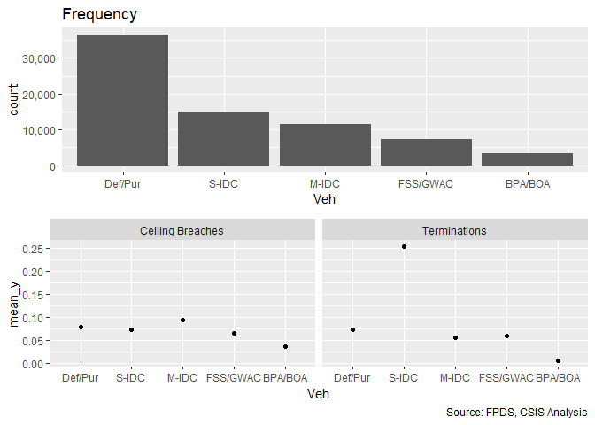

```
## [[1]]
##
##  Def/Pur    S-IDC    M-IDC FSS/GWAC  BPA/BOA
##    36654    15060    11591     7403     3454
##
## [[2]]
##
##             None Ceiling Breach
##   Def/Pur  33742           2912
##   S-IDC    13958           1102
##   M-IDC    10504           1087
##   FSS/GWAC  6911            492
##   BPA/BOA   3328            126
##
## [[3]]
##
##                0     1
##   Def/Pur  33985  2669
##   S-IDC    11237  3823
##   M-IDC    10945   646
##   FSS/GWAC  6961   442
##   BPA/BOA   3434    20
```

```r
summary_discrete_plot(serv_opt,"Veh")
```

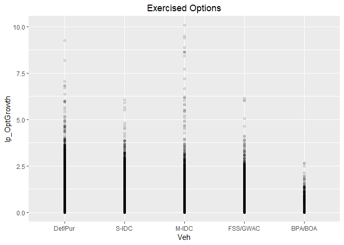

```r
#Scatter Plot
ggplot(serv_opt, aes(x=Veh, y=lp_OptGrowth)) + geom_point(alpha = 0.1) + ggtitle('Exercised Options') + theme(plot.title = element_text(hjust = 0.5))
```

```r
#Model
n_Opt_06A <- glm (data=serv_opt,
                 ln_OptGrowth ~ Veh)
display(n_Opt_06A)
```

```
## glm(formula = ln_OptGrowth ~ Veh, data = serv_opt)
##             coef.est coef.se
## (Intercept)  7.41     0.03
## VehS-IDC    -1.16     0.06
## VehM-IDC     1.47     0.06
## VehFSS/GWAC  1.14     0.07
## VehBPA/BOA  -6.08     0.10
## ---
##   n = 74162, k = 5
##   residual deviance = 2405319.9, null deviance = 2585789.3 (difference = 180469.3)
##   overdispersion parameter = 32.4
##   residual sd is sqrt(overdispersion) = 5.70
```

```r
p_Opt_06A <- glm(data=serv_opt,
                        lp_OptGrowth ~ Veh)

display(p_Opt_06A)
```

```
## glm(formula = lp_OptGrowth ~ Veh, data = serv_opt)
##             coef.est coef.se
## (Intercept)  0.68     0.00
## VehS-IDC    -0.05     0.01
## VehM-IDC    -0.01     0.01
## VehFSS/GWAC  0.03     0.01
## VehBPA/BOA  -0.60     0.01
## ---
##   n = 74162, k = 5
##   residual deviance = 33753.1, null deviance = 34944.5 (difference = 1191.5)
##   overdispersion parameter = 0.5
##   residual sd is sqrt(overdispersion) = 0.67
```

```r
#Plot residuals versus fitted
stargazer::stargazer(n_Opt_05B,n_Opt_06A,

                       p_Opt_05B,p_Opt_06A,
                       type="text",
                       digits=2)
```

```
##
## ======================================================================
##                                       Dependent variable:
##                          ---------------------------------------------
##                               ln_OptGrowth           lp_OptGrowth
##                              (1)         (2)        (3)        (4)
## ----------------------------------------------------------------------
## cl_US6_avg_sal_lag1Const    -0.07                 -0.06***
##                            (0.05)                  (0.01)
##
## cl_CFTE                   -0.78***                -0.14***
##                            (0.05)                  (0.01)
##
## c_pPBSC                    0.18***                -0.02***
##                            (0.05)                  (0.01)
##
## c_pOffPSC                  1.12***                0.26***
##                            (0.06)                  (0.01)
##
## c_pairHist                 0.27***                -0.0001
##                            (0.05)                  (0.01)
##
## cl_pairCA                 -1.34***                -0.10***
##                            (0.06)                  (0.01)
##
## cl_Ceil                    3.57***                0.14***
##                            (0.04)                  (0.01)
##
## capped_cl_Days             2.39***                0.14***
##                            (0.06)                  (0.01)
##
## Comp1or51 offer           -0.36***                 -0.01
##                            (0.06)                  (0.01)
##
## Comp1or52-4 offers        -0.22***                 -0.01*
##                            (0.06)                  (0.01)
##
## Comp1or55+ offers          -0.12**                0.04***
##                            (0.06)                  (0.01)
##
## VehS-IDC                              -1.16***               -0.05***
##                                        (0.06)                 (0.01)
##
## VehM-IDC                               1.47***               -0.01**
##                                        (0.06)                 (0.01)
##
## VehFSS/GWAC                            1.14***               0.03***
##                                        (0.07)                 (0.01)
##
## VehBPA/BOA                            -6.08***               -0.60***
##                                        (0.10)                 (0.01)
##
## Constant                   5.04***     7.41***    0.53***    0.68***
##                            (0.05)      (0.03)      (0.01)    (0.004)
##
## ----------------------------------------------------------------------
## Observations               74,162      74,162      74,162     74,162
## Log Likelihood           -231,270.20 -234,244.00 -75,715.88 -76,042.86
## Akaike Inf. Crit.        462,564.30  468,498.00  151,455.80 152,095.70
## ======================================================================
## Note:                                      *p<0.1; **p<0.05; ***p<0.01
```

```r
#summary_residual_compare(n_Opt_05D,n_Opt_06A)
```

For ceiling breaches, IDCs, particularly multiaward IDCs, were more likely to have breaches contrary to expecatitions.

Expectations were largely upheld for options exercised, with the exception of FSS/GWAC.

#### 06B: Cumulative Model

```r
#Model
n_Opt_06B <- glm (data=serv_opt,
                 ln_OptGrowth ~  cl_US6_avg_sal_lag1Const +
                   cl_CFTE+ c_pPBSC+c_pOffPSC+
                 c_pairHist+cl_pairCA +
                   cl_Ceil + capped_cl_Days+
                   Comp1or5+
                   Veh)
glmer_examine(n_Opt_06B)
```

```
##                              GVIF Df GVIF^(1/(2*Df))
## cl_US6_avg_sal_lag1Const 1.645123  1        1.282624
## cl_CFTE                  1.507873  1        1.227955
## c_pPBSC                  1.287458  1        1.134662
## c_pOffPSC                1.890568  1        1.374979
## c_pairHist               1.506326  1        1.227325
## cl_pairCA                2.711533  1        1.646673
## cl_Ceil                  1.337140  1        1.156348
## capped_cl_Days           1.103826  1        1.050631
## Comp1or5                 1.478597  3        1.067354
## Veh                      3.330809  4        1.162301
```

```r
p_Opt_06B <- glm(data=serv_opt,
                        lp_OptGrowth ~  cl_US6_avg_sal_lag1Const +
                   cl_CFTE+ c_pPBSC+c_pOffPSC+
                 c_pairHist+cl_pairCA+
                 cl_Ceil + capped_cl_Days+
                 Comp1or5+
                   Veh)

glmer_examine(p_Opt_06B)
```

```
##                              GVIF Df GVIF^(1/(2*Df))
## cl_US6_avg_sal_lag1Const 1.645123  1        1.282624
## cl_CFTE                  1.507873  1        1.227955
## c_pPBSC                  1.287458  1        1.134662
## c_pOffPSC                1.890568  1        1.374979
## c_pairHist               1.506326  1        1.227325
## cl_pairCA                2.711533  1        1.646673
## cl_Ceil                  1.337140  1        1.156348
## capped_cl_Days           1.103826  1        1.050631
## Comp1or5                 1.478597  3        1.067354
## Veh                      3.330809  4        1.162301
```

```r
#Plot residuals versus fitted

stargazer::stargazer(n_Opt_05B,n_Opt_06A,n_Opt_06B,

                       p_Opt_05B,p_Opt_06A,p_Opt_06B,
                       type="text",
                       digits=2)
```

```
##
## =============================================================================================
##                                                  Dependent variable:
##                          --------------------------------------------------------------------
##                                     ln_OptGrowth                       lp_OptGrowth
##                              (1)         (2)         (3)        (4)        (5)        (6)
## ---------------------------------------------------------------------------------------------
## cl_US6_avg_sal_lag1Const    -0.07                  0.12***    -0.06***              -0.02***
##                            (0.05)                  (0.05)      (0.01)                (0.01)
##
## cl_CFTE                   -0.78***                -0.51***    -0.14***              -0.10***
##                            (0.05)                  (0.05)      (0.01)                (0.01)
##
## c_pPBSC                    0.18***                 0.44***    -0.02***              0.03***
##                            (0.05)                  (0.05)      (0.01)                (0.01)
##
## c_pOffPSC                  1.12***                 1.31***    0.26***               0.27***
##                            (0.06)                  (0.06)      (0.01)                (0.01)
##
## c_pairHist                 0.27***                 0.32***    -0.0001                0.002
##                            (0.05)                  (0.05)      (0.01)                (0.01)
##
## cl_pairCA                 -1.34***                -0.75***    -0.10***              -0.02***
##                            (0.06)                  (0.06)      (0.01)                (0.01)
##
## cl_Ceil                    3.57***                 3.11***    0.14***               0.08***
##                            (0.04)                  (0.05)      (0.01)                (0.01)
##
## capped_cl_Days             2.39***                 2.20***    0.14***               0.12***
##                            (0.06)                  (0.06)      (0.01)                (0.01)
##
## Comp1or51 offer           -0.36***                -0.40***     -0.01                 -0.001
##                            (0.06)                  (0.06)      (0.01)                (0.01)
##
## Comp1or52-4 offers        -0.22***                -0.17***     -0.01*                 0.01
##                            (0.06)                  (0.06)      (0.01)                (0.01)
##
## Comp1or55+ offers          -0.12**                 0.31***    0.04***               0.10***
##                            (0.06)                  (0.06)      (0.01)                (0.01)
##
## VehS-IDC                              -1.16***    -1.69***               -0.05***   -0.20***
##                                        (0.06)      (0.07)                 (0.01)     (0.01)
##
## VehM-IDC                               1.47***      -0.08                -0.01**    -0.08***
##                                        (0.06)      (0.07)                 (0.01)     (0.01)
##
## VehFSS/GWAC                            1.14***     0.50***               0.03***    0.02***
##                                        (0.07)      (0.07)                 (0.01)     (0.01)
##
## VehBPA/BOA                            -6.08***    -4.06***               -0.60***   -0.61***
##                                        (0.10)      (0.12)                 (0.01)     (0.01)
##
## Constant                   5.04***     7.41***     5.70***    0.53***    0.68***    0.62***
##                            (0.05)      (0.03)      (0.05)      (0.01)    (0.004)     (0.01)
##
## ---------------------------------------------------------------------------------------------
## Observations               74,162      74,162      74,162      74,162     74,162     74,162
## Log Likelihood           -231,270.20 -234,244.00 -230,483.80 -75,715.88 -76,042.86 -74,742.38
## Akaike Inf. Crit.        462,564.30  468,498.00  460,999.50  151,455.80 152,095.70 149,516.80
## =============================================================================================
## Note:                                                             *p<0.1; **p<0.05; ***p<0.01
```

```r
#summary_residual_compare(n_Opt_05B,n_Opt_06B)
```

Expectations for vehicle are now upheld for both ceiling breaches and terminations. For other variables the addition of vehicle proved less pivotal, though coefficients were often decreased.

### Type of Contract

The next step adds a measure for whether the contract was cost-based or fixed-price.

Expectation Prior CSIS research has found that fixed-price contracts estimate a higher probability of terminations but did not find a notable relationship for ceiling breaches.

#### 07A: FFP / Other FP / Incentive / T&M/FP:LOE;LH / Other CB / Combination

Firm-Fixed Price (base) + ++ + Other Fixed Price - - - Time & Materials / Labor Hours / FP: LoE + - - Incentive Fee (both FPIF or CBIF) - - + Other Cost Based - - - Undefinitized Contract Award ++ ++ – Combination + + -

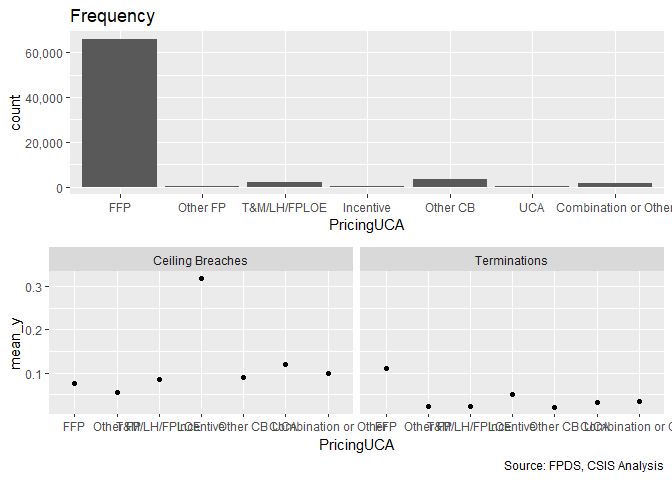

```
## [[1]]
##
##                  FFP             Other FP         T&M/LH/FPLOE
##                66114                  301                 1998
##            Incentive             Other CB                  UCA
##                  116                 3514                  462
## Combination or Other
##                 1657
##
## [[2]]
##
##                         None Ceiling Breach
##   FFP                  61152           4962
##   Other FP               284             17
##   T&M/LH/FPLOE          1829            169
##   Incentive               79             37
##   Other CB              3201            313
##   UCA                    407             55
##   Combination or Other  1491            166
##
## [[3]]
##
##                            0     1
##   FFP                  58717  7397
##   Other FP               294     7
##   T&M/LH/FPLOE          1950    48
##   Incentive              110     6
##   Other CB              3443    71
##   UCA                    447    15
##   Combination or Other  1601    56
```

```r
serv_opt$PricingUCA<-factor(serv_opt$PricingUCA,
                            levels=c( "FFP","Other FP","T&M/LH/FPLOE","Incentive","Other CB","UCA" ,"Combination or Other" ))
serv_opt$PricingUCA<-factor(serv_opt$PricingUCA,
                            levels=c( "FFP","Other FP","T&M/LH/FPLOE","Incentive","Other CB","UCA" ,"Combination or Other" ))
  summary_discrete_plot(serv_opt,"PricingUCA")
```

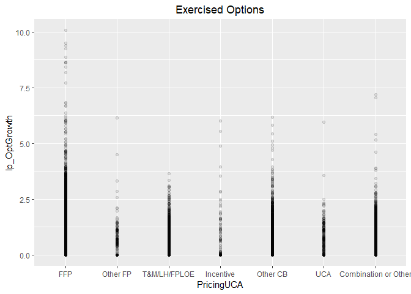

```r
#Scatter Plot
ggplot(serv_opt, aes(x=PricingUCA, y=lp_OptGrowth)) + geom_point(alpha = 0.1) + ggtitle('Exercised Options') + theme(plot.title = element_text(hjust = 0.5))
```

```r
#Model
n_Opt_07A <- glm (data=serv_opt,
                 ln_OptGrowth ~ PricingUCA)
display(n_Opt_07A)
```

```
## glm(formula = ln_OptGrowth ~ PricingUCA, data = serv_opt)
##                                coef.est coef.se
## (Intercept)                    6.93     0.02
## PricingUCAOther FP             0.41     0.34
## PricingUCAT&M/LH/FPLOE         1.93     0.13
## PricingUCAIncentive            2.92     0.54
## PricingUCAOther CB             3.60     0.10
## PricingUCAUCA                  0.37     0.27
## PricingUCACombination or Other 3.37     0.14
## ---
##   n = 74162, k = 7
##   residual deviance = 2519799.9, null deviance = 2585789.3 (difference = 65989.4)
##   overdispersion parameter = 34.0
##   residual sd is sqrt(overdispersion) = 5.83
```

```r
p_Opt_07A <- glm(data=serv_opt,
                        lp_OptGrowth ~ PricingUCA)

display(p_Opt_07A)
```

```
## glm(formula = lp_OptGrowth ~ PricingUCA, data = serv_opt)
##                                coef.est coef.se
## (Intercept)                     0.64     0.00
## PricingUCAOther FP             -0.12     0.04
## PricingUCAT&M/LH/FPLOE         -0.02     0.02
## PricingUCAIncentive             0.14     0.06
## PricingUCAOther CB              0.11     0.01
## PricingUCAUCA                  -0.14     0.03
## PricingUCACombination or Other  0.17     0.02
## ---
##   n = 74162, k = 7
##   residual deviance = 34842.9, null deviance = 34944.5 (difference = 101.6)
##   overdispersion parameter = 0.5
##   residual sd is sqrt(overdispersion) = 0.69
```

```r
#Plot residuals versus fitted
stargazer::stargazer(n_Opt_06B,n_Opt_07A,

                       p_Opt_06B,p_Opt_07A,
                       type="text",
                       digits=2)
```

```
##
## ============================================================================
##                                             Dependent variable:
##                                ---------------------------------------------
##                                     ln_OptGrowth           lp_OptGrowth
##                                    (1)         (2)        (3)        (4)
## ----------------------------------------------------------------------------
## cl_US6_avg_sal_lag1Const         0.12***                -0.02***
##                                  (0.05)                  (0.01)
##
## cl_CFTE                         -0.51***                -0.10***
##                                  (0.05)                  (0.01)
##
## c_pPBSC                          0.44***                0.03***
##                                  (0.05)                  (0.01)
##
## c_pOffPSC                        1.31***                0.27***
##                                  (0.06)                  (0.01)
##
## c_pairHist                       0.32***                 0.002
##                                  (0.05)                  (0.01)
##
## cl_pairCA                       -0.75***                -0.02***
##                                  (0.06)                  (0.01)
##
## cl_Ceil                          3.11***                0.08***
##                                  (0.05)                  (0.01)
##
## capped_cl_Days                   2.20***                0.12***
##                                  (0.06)                  (0.01)
##
## Comp1or51 offer                 -0.40***                 -0.001
##                                  (0.06)                  (0.01)
##
## Comp1or52-4 offers              -0.17***                  0.01
##                                  (0.06)                  (0.01)
##
## Comp1or55+ offers                0.31***                0.10***
##                                  (0.06)                  (0.01)
##
```

[output cut: 24 more lines]

```
## PricingUCAUCA                                 0.37                 -0.14***
##                                              (0.27)                 (0.03)
##
## PricingUCACombination or Other               3.37***               0.17***
##                                              (0.14)                 (0.02)
##
## Constant                         5.70***     6.93***    0.62***    0.64***
##                                  (0.05)      (0.02)      (0.01)    (0.003)
##
## ----------------------------------------------------------------------------
## Observations                     74,162      74,162      74,162     74,162
## Log Likelihood                 -230,483.80 -235,968.20 -74,742.38 -77,221.23
## Akaike Inf. Crit.              460,999.50  471,950.30  149,516.80 154,456.50
## ============================================================================
## Note:                                            *p<0.1; **p<0.05; ***p<0.01
```

```r
#summary_residual_compare(n_Opt_06B,n_Opt_07A,30)
```

Other fixed price and other cost based aligned with expecations for ceiling breaches. For terminations, other fixed price, incentive, cost-based, were line with expectations. For options exercied Other fixed-price, incentive, and UCA were in line with expectations

#### 07B: Cumulative Model

```r
#Model
n_Opt_07B <- glm (data=serv_opt,
                 ln_OptGrowth ~  cl_US6_avg_sal_lag1Const +
                   cl_CFTE+ c_pPBSC+c_pOffPSC+
                 c_pairHist+cl_pairCA +
                   cl_Ceil + capped_cl_Days+
                   Comp1or5+
                   Veh+
                   PricingUCA)
glmer_examine(n_Opt_07B)
```

```
##                              GVIF Df GVIF^(1/(2*Df))
## cl_US6_avg_sal_lag1Const 1.663464  1        1.289754
## cl_CFTE                  1.510955  1        1.229209
## c_pPBSC                  1.295574  1        1.138233
## c_pOffPSC                1.901164  1        1.378827
## c_pairHist               1.516754  1        1.231566
## cl_pairCA                2.728989  1        1.651965
## cl_Ceil                  1.440073  1        1.200030
## capped_cl_Days           1.106597  1        1.051949
## Comp1or5                 1.506657  3        1.070703
## Veh                      3.525892  4        1.170600
## PricingUCA               1.317745  6        1.023260
```

```r
p_Opt_07B <- glm(data=serv_opt,
                        lp_OptGrowth ~  cl_US6_avg_sal_lag1Const +
                   cl_CFTE+ c_pPBSC+c_pOffPSC+
                 c_pairHist+cl_pairCA+
                 cl_Ceil + capped_cl_Days+
                 Comp1or5+
                   Veh+
                   PricingUCA)

glmer_examine(p_Opt_07B)
```

```
##                              GVIF Df GVIF^(1/(2*Df))
## cl_US6_avg_sal_lag1Const 1.663464  1        1.289754
## cl_CFTE                  1.510955  1        1.229209
## c_pPBSC                  1.295574  1        1.138233
## c_pOffPSC                1.901164  1        1.378827
## c_pairHist               1.516754  1        1.231566
## cl_pairCA                2.728989  1        1.651965
## cl_Ceil                  1.440073  1        1.200030
## capped_cl_Days           1.106597  1        1.051949
## Comp1or5                 1.506657  3        1.070703
## Veh                      3.525892  4        1.170600
## PricingUCA               1.317745  6        1.023260
```

```r
#Plot residuals versus fitted

stargazer::stargazer(n_Opt_06B,n_Opt_07A,n_Opt_07B,

                       p_Opt_06B,p_Opt_07A,p_Opt_07B,
                       type="text",
                       digits=2)
```

```
##
## ===================================================================================================
##                                                        Dependent variable:
##                                --------------------------------------------------------------------
##                                           ln_OptGrowth                       lp_OptGrowth
##                                    (1)         (2)         (3)        (4)        (5)        (6)
## ---------------------------------------------------------------------------------------------------
## cl_US6_avg_sal_lag1Const         0.12***                  0.04      -0.02***              -0.03***
##                                  (0.05)                  (0.05)      (0.01)                (0.01)
##
## cl_CFTE                         -0.51***                -0.51***    -0.10***              -0.10***
##                                  (0.05)                  (0.05)      (0.01)                (0.01)
##
## c_pPBSC                          0.44***                 0.39***    0.03***               0.03***
##                                  (0.05)                  (0.05)      (0.01)                (0.01)
##
## c_pOffPSC                        1.31***                 1.37***    0.27***               0.27***
##                                  (0.06)                  (0.06)      (0.01)                (0.01)
##
## c_pairHist                       0.32***                 0.31***     0.002                 0.003
##                                  (0.05)                  (0.05)      (0.01)                (0.01)
##
## cl_pairCA                       -0.75***                -0.83***    -0.02***              -0.03***
##                                  (0.06)                  (0.06)      (0.01)                (0.01)
##
## cl_Ceil                          3.11***                 2.90***    0.08***               0.07***
##                                  (0.05)                  (0.05)      (0.01)                (0.01)
##
## capped_cl_Days                   2.20***                 2.15***    0.12***               0.12***
##                                  (0.06)                  (0.06)      (0.01)                (0.01)
##
## Comp1or51 offer                 -0.40***                -0.44***     -0.001                -0.004
##                                  (0.06)                  (0.06)      (0.01)                (0.01)
##
## Comp1or52-4 offers              -0.17***                -0.20***      0.01                  0.01
##                                  (0.06)                  (0.06)      (0.01)                (0.01)
##
## Comp1or55+ offers                0.31***                 0.39***    0.10***               0.11***
##                                  (0.06)                  (0.06)      (0.01)                (0.01)
##
```

[output cut: 24 more lines]

```
## PricingUCAUCA                                 0.37        -0.14                -0.14***   -0.09***
##                                              (0.27)      (0.25)                 (0.03)     (0.03)
##
## PricingUCACombination or Other               3.37***     1.70***               0.17***    0.15***
##                                              (0.14)      (0.14)                 (0.02)     (0.02)
##
## Constant                         5.70***     6.93***     5.70***    0.62***    0.64***    0.62***
##                                  (0.05)      (0.02)      (0.05)      (0.01)    (0.003)     (0.01)
##
## ---------------------------------------------------------------------------------------------------
## Observations                     74,162      74,162      74,162      74,162     74,162     74,162
## Log Likelihood                 -230,483.80 -235,968.20 -230,299.60 -74,742.38 -77,221.23 -74,660.29
## Akaike Inf. Crit.              460,999.50  471,950.30  460,643.10  149,516.80 154,456.50 149,364.60
## ===================================================================================================
## Note:                                                                   *p<0.1; **p<0.05; ***p<0.01
```

```r
#summary_residual_compare(n_Opt_06B,n_Opt_07B)
#summary_residual_compare(n_Opt_07A,n_Opt_07B,bins=3)
```

Incentive contracts are no longer significantly associated with a greater risk of ceiling breaches, though they have also lost significance in options. Suprirsingly, UCA and Combination or Other have both become significant in for lower risk of ceiling breaches.

### Crisis Dataset

Expectation: Service Contract replying on crisis funds would have more likelihood of cost-ceiling breaches and exercised options but less terminations.

#### 08A: Crisis Funding

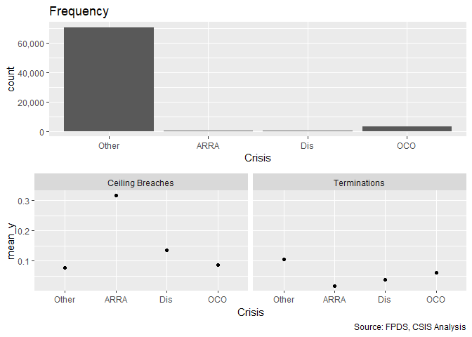

```
## [[1]]
##
## Other  ARRA   Dis   OCO
## 70759   189    52  3162
##
## [[2]]
##
##          None Ceiling Breach
##   Other 65378           5381
##   ARRA    129             60
##   Dis      45              7
##   OCO    2891            271
##
## [[3]]
##
##             0     1
##   Other 63355  7404
##   ARRA    186     3
##   Dis      50     2
##   OCO    2971   191
```

```r
summary_discrete_plot(serv_opt,"Crisis")
```

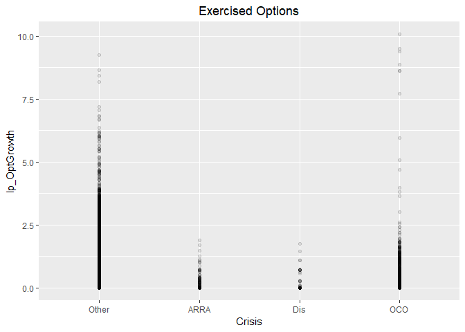

```r
#Scatter Plot
ggplot(serv_opt, aes(x=Crisis, y=lp_OptGrowth)) + geom_point(alpha = 0.1) + ggtitle('Exercised Options') + theme(plot.title = element_text(hjust = 0.5))
```

```r
#Model
n_Opt_08A <- glm (data=serv_opt,
                 ln_OptGrowth ~ Crisis)
display(n_Opt_08A)
```

```
## glm(formula = ln_OptGrowth ~ Crisis, data = serv_opt)
##             coef.est coef.se
## (Intercept)  7.45     0.02
## CrisisARRA  -1.61     0.42
## CrisisDis   -2.11     0.81
## CrisisOCO   -4.72     0.11
## ---
##   n = 74162, k = 4
##   residual deviance = 2517833.8, null deviance = 2585789.3 (difference = 67955.5)
##   overdispersion parameter = 34.0
##   residual sd is sqrt(overdispersion) = 5.83
```

```r
p_Opt_08A <- glm(data=serv_opt,
                        lp_OptGrowth ~ Crisis)

display(p_Opt_08A)
```

```
## glm(formula = lp_OptGrowth ~ Crisis, data = serv_opt)
##             coef.est coef.se
## (Intercept)  0.67     0.00
## CrisisARRA  -0.49     0.05
## CrisisDis   -0.40     0.09
## CrisisOCO   -0.48     0.01
## ---
##   n = 74162, k = 4
##   residual deviance = 34188.5, null deviance = 34944.5 (difference = 756.1)
##   overdispersion parameter = 0.5
##   residual sd is sqrt(overdispersion) = 0.68
```

```r
#Plot residuals versus fitted
stargazer::stargazer(n_Opt_07B,n_Opt_08A,

                       p_Opt_07B,p_Opt_08A,
                       type="text",
                       digits=2)
```

```
##
## ============================================================================
##                                             Dependent variable:
##                                ---------------------------------------------
##                                     ln_OptGrowth           lp_OptGrowth
##                                    (1)         (2)        (3)        (4)
## ----------------------------------------------------------------------------
## cl_US6_avg_sal_lag1Const          0.04                  -0.03***
##                                  (0.05)                  (0.01)
##
## cl_CFTE                         -0.51***                -0.10***
##                                  (0.05)                  (0.01)
##
## c_pPBSC                          0.39***                0.03***
##                                  (0.05)                  (0.01)
##
## c_pOffPSC                        1.37***                0.27***
##                                  (0.06)                  (0.01)
##
## c_pairHist                       0.31***                 0.003
##                                  (0.05)                  (0.01)
##
## cl_pairCA                       -0.83***                -0.03***
##                                  (0.06)                  (0.01)
##
## cl_Ceil                          2.90***                0.07***
##                                  (0.05)                  (0.01)
##
## capped_cl_Days                   2.15***                0.12***
##                                  (0.06)                  (0.01)
##
## Comp1or51 offer                 -0.44***                 -0.004
##                                  (0.06)                  (0.01)
##
## Comp1or52-4 offers              -0.20***                  0.01
##                                  (0.06)                  (0.01)
##
## Comp1or55+ offers                0.39***                0.11***
##                                  (0.06)                  (0.01)
##
```

[output cut: 33 more lines]

```
## CrisisDis                                   -2.11***               -0.40***
##                                              (0.81)                 (0.09)
##
## CrisisOCO                                   -4.72***               -0.48***
##                                              (0.11)                 (0.01)
##
## Constant                         5.70***     7.45***    0.62***    0.67***
##                                  (0.05)      (0.02)      (0.01)    (0.003)
##
## ----------------------------------------------------------------------------
## Observations                     74,162      74,162      74,162     74,162
## Log Likelihood                 -230,299.60 -235,939.20 -74,660.29 -76,518.14
## Akaike Inf. Crit.              460,643.10  471,886.50  149,364.60 153,044.30
## ============================================================================
## Note:                                            *p<0.1; **p<0.05; ***p<0.01
```

```r
# summary_residual_compare(n_Opt_07B,n_Opt_08A,30)
```

For ceiling breaches ARRA and Disaster results were in keeping with expcetations but OCO results were not. There were no significant results for terminations. For options, contrary to exepectation, all forms of crisis funding have a lower rate of usage.

#### 08B: Cumulative Model

```r
#Model
n_Opt_08B <- glm (data=serv_opt,
                 ln_OptGrowth ~  cl_US6_avg_sal_lag1Const +
                   cl_CFTE+ c_pPBSC+c_pOffPSC+
                 c_pairHist+cl_pairCA +
                   cl_Ceil + capped_cl_Days+
                   Comp1or5+
                   Veh+
                   PricingUCA+
                   Crisis)
glmer_examine(n_Opt_08B)
```

```
##                              GVIF Df GVIF^(1/(2*Df))
## cl_US6_avg_sal_lag1Const 1.668936  1        1.291873
## cl_CFTE                  1.540381  1        1.241121
## c_pPBSC                  1.311735  1        1.145310
## c_pOffPSC                1.972074  1        1.404305
## c_pairHist               1.538851  1        1.240504
## cl_pairCA                3.182145  1        1.783857
## cl_Ceil                  1.466749  1        1.211094
## capped_cl_Days           1.159788  1        1.076935
## Comp1or5                 1.529970  3        1.073447
## Veh                      3.718660  4        1.178415
## PricingUCA               1.325984  6        1.023792
## Crisis                   1.375439  3        1.054566
```

```r
p_Opt_08B <- glm(data=serv_opt,
                        lp_OptGrowth ~  cl_US6_avg_sal_lag1Const +
                   cl_CFTE+ c_pPBSC+c_pOffPSC+
                 c_pairHist+cl_pairCA+
                 cl_Ceil + capped_cl_Days+
                 Comp1or5+
                   Veh+
                   PricingUCA+
                   Crisis)

glmer_examine(p_Opt_08B)
```

```
##                              GVIF Df GVIF^(1/(2*Df))
## cl_US6_avg_sal_lag1Const 1.668936  1        1.291873
## cl_CFTE                  1.540381  1        1.241121
## c_pPBSC                  1.311735  1        1.145310
## c_pOffPSC                1.972074  1        1.404305
## c_pairHist               1.538851  1        1.240504
## cl_pairCA                3.182145  1        1.783857
## cl_Ceil                  1.466749  1        1.211094
## capped_cl_Days           1.159788  1        1.076935
## Comp1or5                 1.529970  3        1.073447
## Veh                      3.718660  4        1.178415
## PricingUCA               1.325984  6        1.023792
## Crisis                   1.375439  3        1.054566
```

```r
#Plot residuals versus fitted

stargazer::stargazer(n_Opt_07B,n_Opt_08A,n_Opt_08B,

                       p_Opt_07B,p_Opt_08A,p_Opt_08B,
                       type="text",
                       digits=2)
```

```
##
## ===================================================================================================
##                                                        Dependent variable:
##                                --------------------------------------------------------------------
##                                           ln_OptGrowth                       lp_OptGrowth
##                                    (1)         (2)         (3)        (4)        (5)        (6)
## ---------------------------------------------------------------------------------------------------
## cl_US6_avg_sal_lag1Const          0.04                   0.15***    -0.03***              -0.02***
##                                  (0.05)                  (0.05)      (0.01)                (0.01)
##
## cl_CFTE                         -0.51***                -0.80***    -0.10***              -0.13***
##                                  (0.05)                  (0.05)      (0.01)                (0.01)
##
## c_pPBSC                          0.39***                 0.17***    0.03***                -0.002
##                                  (0.05)                  (0.05)      (0.01)                (0.01)
##
## c_pOffPSC                        1.37***                 0.85***    0.27***               0.20***
##                                  (0.06)                  (0.07)      (0.01)                (0.01)
##
## c_pairHist                       0.31***                  0.09*      0.003                -0.03***
##                                  (0.05)                  (0.05)      (0.01)                (0.01)
##
## cl_pairCA                       -0.83***                 0.15**     -0.03***              0.10***
##                                  (0.06)                  (0.06)      (0.01)                (0.01)
##
## cl_Ceil                          2.90***                 3.16***    0.07***               0.10***
##                                  (0.05)                  (0.05)      (0.01)                (0.01)
##
## capped_cl_Days                   2.15***                 1.59***    0.12***               0.05***
##                                  (0.06)                  (0.06)      (0.01)                (0.01)
##
## Comp1or51 offer                 -0.44***                 -0.13*      -0.004               0.04***
##                                  (0.06)                  (0.06)      (0.01)                (0.01)
##
## Comp1or52-4 offers              -0.20***                  -0.05       0.01                0.03***
##                                  (0.06)                  (0.06)      (0.01)                (0.01)
##
## Comp1or55+ offers                0.39***                 0.49***    0.11***               0.12***
##                                  (0.06)                  (0.06)      (0.01)                (0.01)
##
```

[output cut: 33 more lines]

```
## CrisisDis                                   -2.11***    -2.25***               -0.40***   -0.42***
##                                              (0.81)      (0.74)                 (0.09)     (0.09)
##
## CrisisOCO                                   -4.72***    -4.70***               -0.48***   -0.60***
##                                              (0.11)      (0.11)                 (0.01)     (0.01)
##
## Constant                         5.70***     7.45***     6.21***    0.62***    0.67***    0.69***
##                                  (0.05)      (0.02)      (0.06)      (0.01)    (0.003)     (0.01)
##
## ---------------------------------------------------------------------------------------------------
## Observations                     74,162      74,162      74,162      74,162     74,162     74,162
## Log Likelihood                 -230,299.60 -235,939.20 -229,432.50 -74,660.29 -76,518.14 -73,679.81
## Akaike Inf. Crit.              460,643.10  471,886.50  458,915.00  149,364.60 153,044.30 147,409.60
## ===================================================================================================
## Note:                                                                   *p<0.1; **p<0.05; ***p<0.01
```

```r
#summary_residual_compare(n_Opt_07B,n_Opt_08B)
```

Terminatins for OCO and ARRA are now significant in the expected direction.

## Industrial Sector

### Level 6

#### Model 09A: l_def6_HHI_lag1

HHI (logged, + means more consolidation) cl_def6_HHI_lag1+ + - -

Expectations are unchanged.

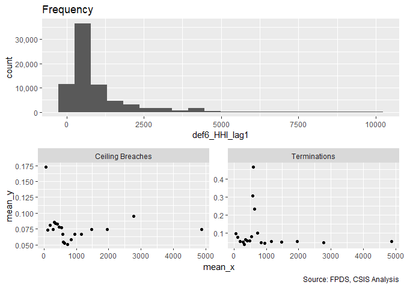

```r
#Frequency Plot for unlogged ceiling
summary_continuous_plot(serv_opt,"def6_HHI_lag1")
```

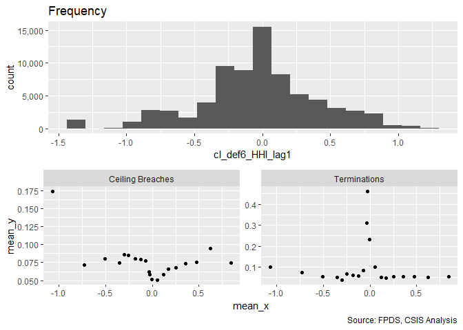

```r
summary_continuous_plot(serv_opt,"cl_def6_HHI_lag1")
```

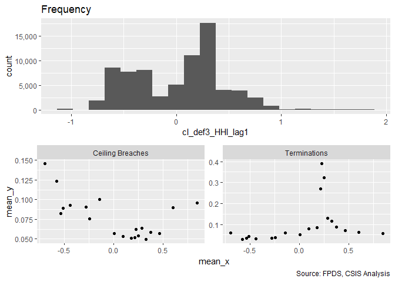

```r
summary_continuous_plot(serv_opt,"cl_def3_HHI_lag1")
```

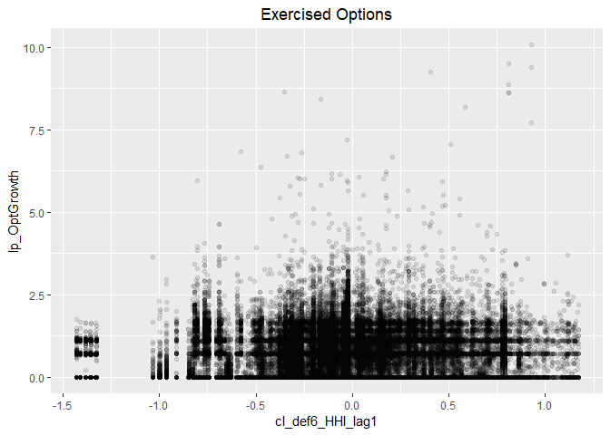

```r
#Scatter Plot
ggplot(serv_opt, aes(x=cl_def6_HHI_lag1, y=lp_OptGrowth)) + geom_point(alpha = 0.1) + ggtitle('Exercised Options') + theme(plot.title = element_text(hjust = 0.5))
```

```r
#Model
n_Opt_09A <- glm (data=serv_opt,
                 ln_OptGrowth ~ cl_def6_HHI_lag1)
display(n_Opt_09A)
```

```
## glm(formula = ln_OptGrowth ~ cl_def6_HHI_lag1, data = serv_opt)
##                  coef.est coef.se
## (Intercept)       7.23     0.02
## cl_def6_HHI_lag1 -0.27     0.05
## ---
##   n = 74162, k = 2
##   residual deviance = 2584746.4, null deviance = 2585789.3 (difference = 1042.8)
##   overdispersion parameter = 34.9
##   residual sd is sqrt(overdispersion) = 5.90
```

```r
p_Opt_09A <- glm(data=serv_opt,
                        lp_OptGrowth ~ cl_def6_HHI_lag1)

display(p_Opt_09A)
```

```
## glm(formula = lp_OptGrowth ~ cl_def6_HHI_lag1, data = serv_opt)
##                  coef.est coef.se
## (Intercept)      0.65     0.00
## cl_def6_HHI_lag1 0.00     0.01
## ---
##   n = 74162, k = 2
##   residual deviance = 34944.5, null deviance = 34944.5 (difference = 0.0)
##   overdispersion parameter = 0.5
##   residual sd is sqrt(overdispersion) = 0.69
```

```r
#Plot residuals versus fitted
stargazer::stargazer(n_Opt_08B,n_Opt_09A,

                       p_Opt_08B,p_Opt_09A,
                       type="text",
                       digits=2)
```

```
##
## ============================================================================
##                                             Dependent variable:
##                                ---------------------------------------------
##                                     ln_OptGrowth           lp_OptGrowth
##                                    (1)         (2)        (3)        (4)
## ----------------------------------------------------------------------------
## cl_US6_avg_sal_lag1Const         0.15***                -0.02***
##                                  (0.05)                  (0.01)
##
## cl_CFTE                         -0.80***                -0.13***
##                                  (0.05)                  (0.01)
##
## c_pPBSC                          0.17***                 -0.002
##                                  (0.05)                  (0.01)
##
## c_pOffPSC                        0.85***                0.20***
##                                  (0.07)                  (0.01)
##
## c_pairHist                        0.09*                 -0.03***
##                                  (0.05)                  (0.01)
##
## cl_pairCA                        0.15**                 0.10***
##                                  (0.06)                  (0.01)
##
## cl_Ceil                          3.16***                0.10***
##                                  (0.05)                  (0.01)
##
## capped_cl_Days                   1.59***                0.05***
##                                  (0.06)                  (0.01)
##
## Comp1or51 offer                  -0.13*                 0.04***
##                                  (0.06)                  (0.01)
##
## Comp1or52-4 offers                -0.05                 0.03***
##                                  (0.06)                  (0.01)
##
## Comp1or55+ offers                0.49***                0.12***
##                                  (0.06)                  (0.01)
##
```

[output cut: 36 more lines]

```
## CrisisOCO                       -4.70***                -0.60***
##                                  (0.11)                  (0.01)
##
## cl_def6_HHI_lag1                            -0.27***               -0.0003
##                                              (0.05)                 (0.01)
##
## Constant                         6.21***     7.23***    0.69***    0.65***
##                                  (0.06)      (0.02)      (0.01)    (0.003)
##
## ----------------------------------------------------------------------------
## Observations                     74,162      74,162      74,162     74,162
## Log Likelihood                 -229,432.50 -236,911.80 -73,679.81 -77,329.23
## Akaike Inf. Crit.              458,915.00  473,827.60  147,409.60 154,662.50
## ============================================================================
## Note:                                            *p<0.1; **p<0.05; ***p<0.01
```

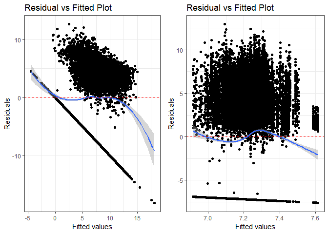

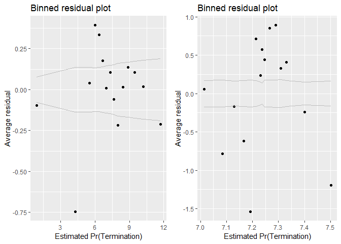

```r
summary_residual_compare(n_Opt_08B,n_Opt_09A, skip_vif = TRUE)
```

Expected direction for ceiling breach and termination, but no real results on options.

#### Model 09B: Defense to Overall ratio

The higher the ratio of defense obligations to reciepts in the overall economy, the DoD holds a monosopy over a sector. Given the challenges of monosopy, the a higher ratio estimates a greater risk of ceiling breaches.

Ratio Def. obligatons : US revenue cl_def6_obl_lag1+ + - -

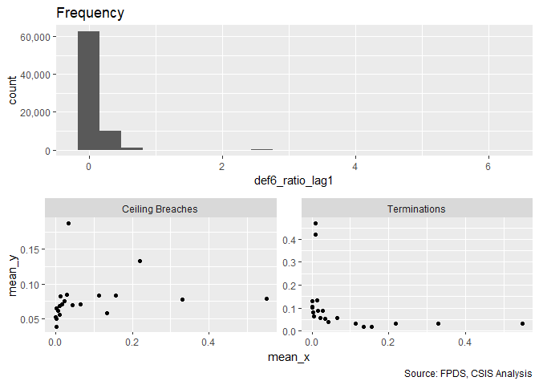

```r
#Frequency Plot for unlogged ceiling
      summary_continuous_plot(serv_opt,"def6_ratio_lag1")
```

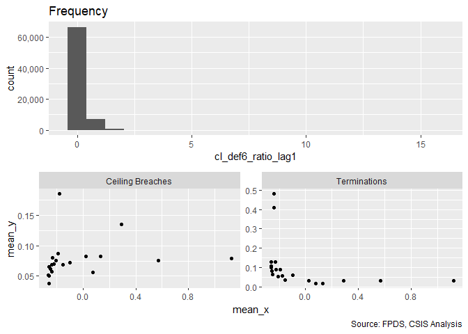

```r
      summary_continuous_plot(serv_opt,"cl_def6_ratio_lag1")
```

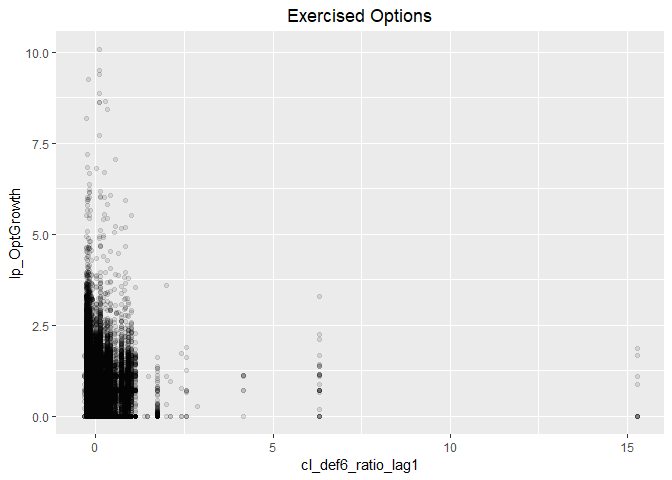

```r
#Scatter Plot
ggplot(serv_opt, aes(x=cl_def6_ratio_lag1, y=lp_OptGrowth)) + geom_point(alpha = 0.1) + ggtitle('Exercised Options') + theme(plot.title = element_text(hjust = 0.5))
```

```r
#Model
n_Opt_09B <- glm (data=serv_opt,
                 ln_OptGrowth ~ cl_def6_ratio_lag1)
display(n_Opt_09B)
```

```
## glm(formula = ln_OptGrowth ~ cl_def6_ratio_lag1, data = serv_opt)
##                    coef.est coef.se
## (Intercept)         7.22     0.02
## cl_def6_ratio_lag1 -0.45     0.05
## ---
##   n = 74162, k = 2
##   residual deviance = 2583292.3, null deviance = 2585789.3 (difference = 2497.0)
##   overdispersion parameter = 34.8
##   residual sd is sqrt(overdispersion) = 5.90
```

```r
p_Opt_09B <- glm(data=serv_opt,
                        lp_OptGrowth ~ cl_def6_ratio_lag1)

display(p_Opt_09B)
```

```
## glm(formula = lp_OptGrowth ~ cl_def6_ratio_lag1, data = serv_opt)
##                    coef.est coef.se
## (Intercept)         0.64     0.00
## cl_def6_ratio_lag1 -0.17     0.01
## ---
##   n = 74162, k = 2
##   residual deviance = 34590.9, null deviance = 34944.5 (difference = 353.6)
##   overdispersion parameter = 0.5
##   residual sd is sqrt(overdispersion) = 0.68
```

```r
#Plot residuals versus fitted
stargazer::stargazer(n_Opt_08B,n_Opt_09A,n_Opt_09B,

                       p_Opt_08B,p_Opt_09A,p_Opt_09B,
                       type="text",
                       digits=2)
```

```
##
## ===================================================================================================
##                                                        Dependent variable:
##                                --------------------------------------------------------------------
##                                           ln_OptGrowth                       lp_OptGrowth
##                                    (1)         (2)         (3)        (4)        (5)        (6)
## ---------------------------------------------------------------------------------------------------
## cl_US6_avg_sal_lag1Const         0.15***                            -0.02***
##                                  (0.05)                              (0.01)
##
## cl_CFTE                         -0.80***                            -0.13***
##                                  (0.05)                              (0.01)
##
## c_pPBSC                          0.17***                             -0.002
##                                  (0.05)                              (0.01)
##
## c_pOffPSC                        0.85***                            0.20***
##                                  (0.07)                              (0.01)
##
## c_pairHist                        0.09*                             -0.03***
##                                  (0.05)                              (0.01)
##
## cl_pairCA                        0.15**                             0.10***
##                                  (0.06)                              (0.01)
##
## cl_Ceil                          3.16***                            0.10***
##                                  (0.05)                              (0.01)
##
## capped_cl_Days                   1.59***                            0.05***
##                                  (0.06)                              (0.01)
##
## Comp1or51 offer                  -0.13*                             0.04***
##                                  (0.06)                              (0.01)
##
## Comp1or52-4 offers                -0.05                             0.03***
##                                  (0.06)                              (0.01)
##
## Comp1or55+ offers                0.49***                            0.12***
##                                  (0.06)                              (0.01)
##
```

[output cut: 39 more lines]

```
## cl_def6_HHI_lag1                            -0.27***                           -0.0003
##                                              (0.05)                             (0.01)
##
## cl_def6_ratio_lag1                                      -0.45***                          -0.17***
##                                                          (0.05)                            (0.01)
##
## Constant                         6.21***     7.23***     7.22***    0.69***    0.65***    0.64***
##                                  (0.06)      (0.02)      (0.02)      (0.01)    (0.003)    (0.003)
##
## ---------------------------------------------------------------------------------------------------
## Observations                     74,162      74,162      74,162      74,162     74,162     74,162
## Log Likelihood                 -229,432.50 -236,911.80 -236,890.90 -73,679.81 -77,329.23 -76,952.11
## Akaike Inf. Crit.              458,915.00  473,827.60  473,785.90  147,409.60 154,662.50 153,908.20
## ===================================================================================================
## Note:                                                                   *p<0.1; **p<0.05; ***p<0.01
```

```r
#summary_residual_compare(n_Opt_08B,n_Opt_09B)
#summary_residual_compare(n_Opt_09A,n_Opt_09B)
```

#### Model 09C: Defense Obligations

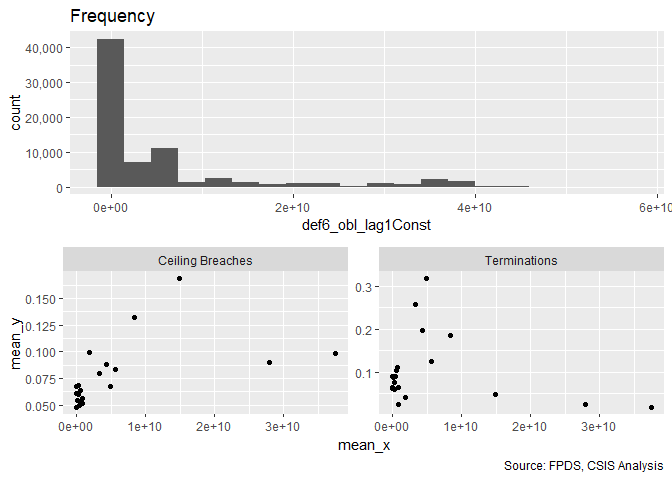

```r
#Frequency Plot for unlogged ceiling
      summary_continuous_plot(serv_opt,"def6_obl_lag1Const")
```

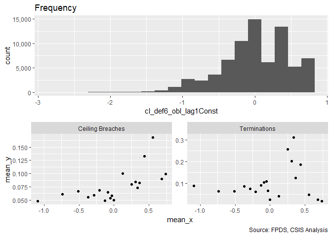

```r
      summary_continuous_plot(serv_opt,"cl_def6_obl_lag1Const")
```

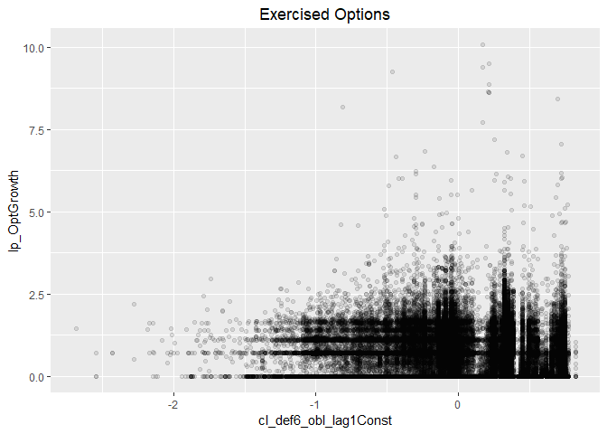

```r
#Scatter Plot
ggplot(serv_opt, aes(x=cl_def6_obl_lag1Const, y=lp_OptGrowth)) + geom_point(alpha = 0.1) + ggtitle('Exercised Options') + theme(plot.title = element_text(hjust = 0.5))
```

```r
#Model
n_Opt_09C <- glm (data=serv_opt,
                 ln_OptGrowth ~ cl_def6_obl_lag1Const)
display(n_Opt_09C)
```

```
## glm(formula = ln_OptGrowth ~ cl_def6_obl_lag1Const, data = serv_opt)
##                       coef.est coef.se
## (Intercept)           7.23     0.02
## cl_def6_obl_lag1Const 0.64     0.05
## ---
##   n = 74162, k = 2
##   residual deviance = 2579302.7, null deviance = 2585789.3 (difference = 6486.6)
##   overdispersion parameter = 34.8
##   residual sd is sqrt(overdispersion) = 5.90
```

```r
p_Opt_09C <- glm(data=serv_opt,
                        lp_OptGrowth ~ cl_def6_obl_lag1Const)

display(p_Opt_09C)
```

```
## glm(formula = lp_OptGrowth ~ cl_def6_obl_lag1Const, data = serv_opt)
##                       coef.est coef.se
## (Intercept)            0.65     0.00
## cl_def6_obl_lag1Const -0.05     0.01
## ---
##   n = 74162, k = 2
##   residual deviance = 34902.2, null deviance = 34944.5 (difference = 42.4)
##   overdispersion parameter = 0.5
##   residual sd is sqrt(overdispersion) = 0.69
```

```r
#Plot residuals versus fitted
stargazer::stargazer(n_Opt_09A,n_Opt_09B,n_Opt_09C,

                       p_Opt_09A,p_Opt_09B,p_Opt_09C,
                       type="text",
                       digits=2)
```

```
##
## ==========================================================================================
##                                               Dependent variable:
##                       --------------------------------------------------------------------
##                                  ln_OptGrowth                       lp_OptGrowth
##                           (1)         (2)         (3)        (4)        (5)        (6)
## ------------------------------------------------------------------------------------------
## cl_def6_HHI_lag1       -0.27***                            -0.0003
##                         (0.05)                              (0.01)
##
## cl_def6_ratio_lag1                 -0.45***                           -0.17***
##                                     (0.05)                             (0.01)
##
## cl_def6_obl_lag1Const                           0.64***                          -0.05***
##                                                 (0.05)                            (0.01)
##
## Constant                7.23***     7.22***     7.23***    0.65***    0.64***    0.65***
##                         (0.02)      (0.02)      (0.02)     (0.003)    (0.003)    (0.003)
##
## ------------------------------------------------------------------------------------------
## Observations            74,162      74,162      74,162      74,162     74,162     74,162
## Log Likelihood        -236,911.80 -236,890.90 -236,833.60 -77,329.23 -76,952.11 -77,284.26
## Akaike Inf. Crit.     473,827.60  473,785.90  473,671.20  154,662.50 153,908.20 154,572.50
## ==========================================================================================
## Note:                                                          *p<0.1; **p<0.05; ***p<0.01
```

```r
#summary_residual_compare(n_Opt_08B,n_Opt_09C)
#summary_residual_compare(n_Opt_09A,n_Opt_09C)
#summary_residual_compare(n_Opt_09B,n_Opt_09C)
```

Contrary to expectation. for termination and options.

#### Model 09D: NAICS 6 Combined

Consolidation at lessa nd more granular levels may have different effects. Efficiencies are often used to describe sectors, like utilities, with high barriers to entry. Many of these aspects seem like they would already be captured at less granular NAICS levels, e.g. power plants, rather than more specific NAICS levels, like solar vs. coal. As a result, consolidation for more granular NAICS codes should estimate higher rates of ceiling breaches compared to less granular NAICS code.

We’ll start by adding in everything from both models and seeing what violates VIF.

```r
#Frequency Plot for unlogged ceiling



#Model
n_Opt_09D <- glm (data=serv_opt,
                 ln_OptGrowth ~ cl_def6_HHI_lag1+cl_def6_ratio_lag1+cl_def6_obl_lag1Const
                 )
glmer_examine(n_Opt_09D)
```

```
##      cl_def6_HHI_lag1    cl_def6_ratio_lag1 cl_def6_obl_lag1Const
##              1.061931              1.269520              1.218054
```

```r
p_Opt_09D <- glm(data=serv_opt,
                        lp_OptGrowth ~ cl_def6_HHI_lag1+cl_def6_ratio_lag1)

glmer_examine(p_Opt_09D)
```

```
##   cl_def6_HHI_lag1 cl_def6_ratio_lag1
##           1.043527           1.043527
```

```r
n_Opt_09D2 <- glm (data=serv_opt,
                 ln_OptGrowth ~ cl_def6_HHI_lag1+cl_def6_ratio_lag1
                 )
glmer_examine(n_Opt_09D2)
```

```
##   cl_def6_HHI_lag1 cl_def6_ratio_lag1
##           1.043527           1.043527
```

```r
p_Opt_09D2 <- glm(data=serv_opt,
                        lp_OptGrowth ~ cl_def6_HHI_lag1+cl_def6_ratio_lag1)

glmer_examine(p_Opt_09D2)
```

```
##   cl_def6_HHI_lag1 cl_def6_ratio_lag1
##           1.043527           1.043527
```

```r
#Plot residuals versus fitted
stargazer::stargazer(n_Opt_09D,n_Opt_09D2,

                     p_Opt_09D,p_Opt_09D2,
                       type="text",
                       digits=2)
```

```
##
## ===================================================================
##                                    Dependent variable:
##                       ---------------------------------------------
##                            ln_OptGrowth           lp_OptGrowth
##                           (1)         (2)        (3)        (4)
## -------------------------------------------------------------------
## cl_def6_HHI_lag1         -0.07     -0.19***    0.03***    0.03***
##                         (0.05)      (0.05)      (0.01)     (0.01)
##
## cl_def6_ratio_lag1     -0.88***    -0.41***    -0.18***   -0.18***
##                         (0.06)      (0.05)      (0.01)     (0.01)
##
## cl_def6_obl_lag1Const   0.95***
##                         (0.05)
##
## Constant                7.19***     7.22***    0.64***    0.64***
##                         (0.02)      (0.02)     (0.003)    (0.003)
##
## -------------------------------------------------------------------
## Observations            74,162      74,162      74,162     74,162
## Log Likelihood        -236,715.00 -236,883.60 -76,935.97 -76,935.97
## Akaike Inf. Crit.     473,437.90  473,773.20  153,877.90 153,877.90
## ===================================================================
## Note:                                   *p<0.1; **p<0.05; ***p<0.01
```

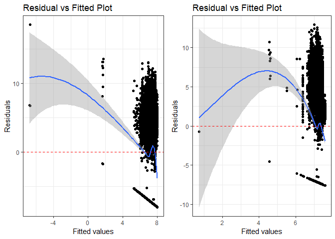

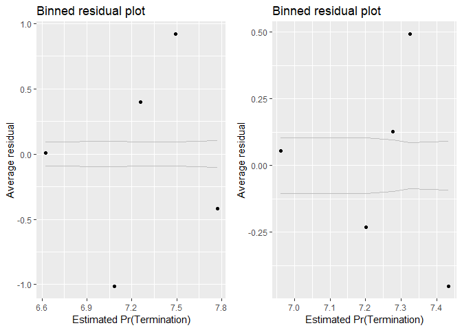

```
## [[1]]
##        model deviance null.deviance difference
## 1 model1_old  2571063       2585789  14726.683
## 2 model1_new  2582783       2585789   3006.091
##
## [[2]]
##   cl_def6_HHI_lag1 cl_def6_ratio_lag1
##           1.043527           1.043527
```

```r
summary_residual_compare(n_Opt_09D,n_Opt_09D2)
```

NAICS Subsector (Level 3)  
HHI (logged, + means more consolidation) cl_def3_HHI_lag1+ + ++ - Ratio Def. obligatons : US revenue cl_def3_ratio_lag1+ + + -

Ratio at either level is no longer in line with expectations for ceiling breaches.

#### Model 09E: Cumulative Model

Consolidation at lessa nd more granular levels may have different effects. Efficiencies are often used to describe sectors, like utilities, with high barriers to entry. Many of these aspects seem like they would already be captured at less granular NAICS levels, e.g. power plants, rather than more specific NAICS levels, like solar vs. coal. As a result, consolidation for more granular NAICS codes should estimate higher rates of ceiling breaches compared to less granular NAICS code.

We’ll start by adding in everything from both models and seeing what violates VIF.

```r
#Frequency Plot for unlogged ceiling


#Model
n_Opt_09E <- glm (data=serv_opt,
                 ln_OptGrowth ~  cl_US6_avg_sal_lag1Const +
                   cl_CFTE+ c_pPBSC+c_pOffPSC+
                 c_pairHist+cl_pairCA +
                   cl_Ceil + capped_cl_Days+
                   Comp1or5+
                   Veh+
                   PricingUCA+
                   Crisis+
                   cl_def6_HHI_lag1+cl_def6_ratio_lag1)
glmer_examine(n_Opt_09E)
```

```
##                              GVIF Df GVIF^(1/(2*Df))
## cl_US6_avg_sal_lag1Const 1.734475  1        1.316995
## cl_CFTE                  1.546206  1        1.243465
## c_pPBSC                  1.314607  1        1.146563
## c_pOffPSC                1.987170  1        1.409670
## c_pairHist               1.547834  1        1.244120
## cl_pairCA                3.205601  1        1.790419
## cl_Ceil                  1.491165  1        1.221133
## capped_cl_Days           1.164772  1        1.079246
## Comp1or5                 1.584884  3        1.079774
## Veh                      3.858606  4        1.183869
## PricingUCA               1.354937  6        1.025636
## Crisis                   1.378950  3        1.055014
## cl_def6_HHI_lag1         1.177332  1        1.085049
## cl_def6_ratio_lag1       1.145491  1        1.070276
```

```r
p_Opt_09E <- glm(data=serv_opt,
                        lp_OptGrowth ~  cl_US6_avg_sal_lag1Const +
                   cl_CFTE+ c_pPBSC+c_pOffPSC+
                 c_pairHist+cl_pairCA+
                 cl_Ceil + capped_cl_Days+
                 Comp1or5+
                   Veh+
                   PricingUCA+
                   Crisis+
                 cl_def6_HHI_lag1+cl_def6_ratio_lag1)

glmer_examine(p_Opt_09E)
```

```
##                              GVIF Df GVIF^(1/(2*Df))
## cl_US6_avg_sal_lag1Const 1.734475  1        1.316995
## cl_CFTE                  1.546206  1        1.243465
## c_pPBSC                  1.314607  1        1.146563
## c_pOffPSC                1.987170  1        1.409670
## c_pairHist               1.547834  1        1.244120
## cl_pairCA                3.205601  1        1.790419
## cl_Ceil                  1.491165  1        1.221133
## capped_cl_Days           1.164772  1        1.079246
## Comp1or5                 1.584884  3        1.079774
## Veh                      3.858606  4        1.183869
## PricingUCA               1.354937  6        1.025636
## Crisis                   1.378950  3        1.055014
## cl_def6_HHI_lag1         1.177332  1        1.085049
## cl_def6_ratio_lag1       1.145491  1        1.070276
```

```r
#Plot residuals versus fitted
stargazer::stargazer(n_Opt_08B,n_Opt_09D2,n_Opt_09E,

                     p_Opt_08B,p_Opt_09D2,p_Opt_09E,
                       type="text",
                       digits=2)
```

```
##
## ===================================================================================================
##                                                        Dependent variable:
##                                --------------------------------------------------------------------
##                                           ln_OptGrowth                       lp_OptGrowth
##                                    (1)         (2)         (3)        (4)        (5)        (6)
## ---------------------------------------------------------------------------------------------------
## cl_US6_avg_sal_lag1Const         0.15***                 0.10**     -0.02***              -0.03***
##                                  (0.05)                  (0.05)      (0.01)                (0.01)
##
## cl_CFTE                         -0.80***                -0.80***    -0.13***              -0.14***
##                                  (0.05)                  (0.05)      (0.01)                (0.01)
##
## c_pPBSC                          0.17***                 0.14***     -0.002                -0.01
##                                  (0.05)                  (0.05)      (0.01)                (0.01)
##
## c_pOffPSC                        0.85***                 0.92***    0.20***               0.22***
##                                  (0.07)                  (0.07)      (0.01)                (0.01)
##
## c_pairHist                        0.09*                  0.14***    -0.03***              -0.01***
##                                  (0.05)                  (0.05)      (0.01)                (0.01)
##
## cl_pairCA                        0.15**                   0.06      0.10***               0.08***
##                                  (0.06)                  (0.06)      (0.01)                (0.01)
##
## cl_Ceil                          3.16***                 3.25***    0.10***               0.12***
##                                  (0.05)                  (0.05)      (0.01)                (0.01)
##
## capped_cl_Days                   1.59***                 1.55***    0.05***               0.04***
##                                  (0.06)                  (0.06)      (0.01)                (0.01)
##
## Comp1or51 offer                  -0.13*                   -0.10     0.04***               0.04***
##                                  (0.06)                  (0.06)      (0.01)                (0.01)
##
## Comp1or52-4 offers                -0.05                   -0.05     0.03***               0.03***
##                                  (0.06)                  (0.06)      (0.01)                (0.01)
##
## Comp1or55+ offers                0.49***                 0.47***    0.12***               0.12***
##                                  (0.06)                  (0.06)      (0.01)                (0.01)
##
```

[output cut: 39 more lines]

```
## cl_def6_HHI_lag1                            -0.19***     0.39***               0.03***    0.10***
##                                              (0.05)      (0.05)                 (0.01)     (0.01)
##
## cl_def6_ratio_lag1                          -0.41***    -0.74***               -0.18***   -0.15***
##                                              (0.05)      (0.05)                 (0.01)     (0.01)
##
## Constant                         6.21***     7.22***     6.13***    0.69***    0.64***    0.67***
##                                  (0.06)      (0.02)      (0.06)      (0.01)    (0.003)     (0.01)
##
## ---------------------------------------------------------------------------------------------------
## Observations                     74,162      74,162      74,162      74,162     74,162     74,162
## Log Likelihood                 -229,432.50 -236,883.60 -229,315.30 -73,679.81 -76,935.97 -73,313.05
## Akaike Inf. Crit.              458,915.00  473,773.20  458,684.70  147,409.60 153,877.90 146,680.10
## ===================================================================================================
## Note:                                                                   *p<0.1; **p<0.05; ***p<0.01
```

```r
#summary_residual_compare(n_Opt_09D2,n_Opt_09E)
#summary_residual_compare(n_Opt_08B,n_Opt_09E)
```

Expectations are not upheld.

### Level 3

#### Model 10A: cl_def3_HHI

HHI (logged, + means more consolidation) cl_def3_HHI_lag1+ + ++ -

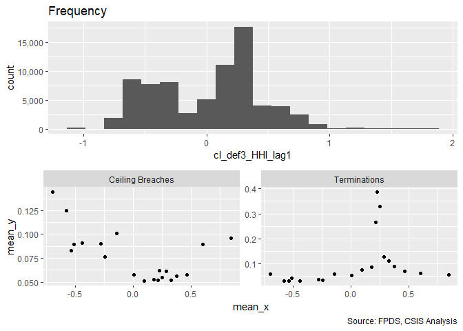

```r
#Frequency Plot for unlogged ceiling
summary_continuous_plot(serv_opt,"cl_def3_HHI_lag1")
```

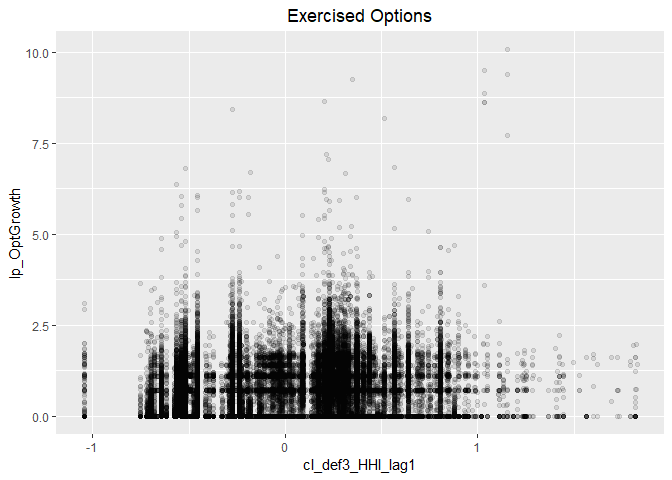

```r
#Scatter Plot
ggplot(serv_opt, aes(x=cl_def3_HHI_lag1, y=lp_OptGrowth)) + geom_point(alpha = 0.1) + ggtitle('Exercised Options') + theme(plot.title = element_text(hjust = 0.5))
```

```r
#Model
n_Opt_10A <- glm (data=serv_opt,
                 ln_OptGrowth ~ cl_def3_HHI_lag1)
display(n_Opt_10A)
```

```
## glm(formula = ln_OptGrowth ~ cl_def3_HHI_lag1, data = serv_opt)
##                  coef.est coef.se
## (Intercept)       7.25     0.02
## cl_def3_HHI_lag1 -0.61     0.05
## ---
##   n = 74162, k = 2
##   residual deviance = 2580903.8, null deviance = 2585789.3 (difference = 4885.4)
##   overdispersion parameter = 34.8
##   residual sd is sqrt(overdispersion) = 5.90
```

```r
p_Opt_10A <- glm(data=serv_opt,
                        lp_OptGrowth ~ cl_def3_HHI_lag1)

display(p_Opt_10A)
```

```
## glm(formula = lp_OptGrowth ~ cl_def3_HHI_lag1, data = serv_opt)
##                  coef.est coef.se
## (Intercept)      0.64     0.00
## cl_def3_HHI_lag1 0.17     0.01
## ---
##   n = 74162, k = 2
##   residual deviance = 34564.2, null deviance = 34944.5 (difference = 380.4)
##   overdispersion parameter = 0.5
##   residual sd is sqrt(overdispersion) = 0.68
```

```r
#Plot residuals versus fitted
stargazer::stargazer(n_Opt_09A,n_Opt_10A,

                       p_Opt_09A,p_Opt_10A,
                       type="text",
                       digits=2)
```

```
##
## ===============================================================
##                                Dependent variable:
##                   ---------------------------------------------
##                        ln_OptGrowth           lp_OptGrowth
##                       (1)         (2)        (3)        (4)
## ---------------------------------------------------------------
## cl_def6_HHI_lag1   -0.27***                -0.0003
##                     (0.05)                  (0.01)
##
## cl_def3_HHI_lag1               -0.61***               0.17***
##                                 (0.05)                 (0.01)
##
## Constant            7.23***     7.25***    0.65***    0.64***
##                     (0.02)      (0.02)     (0.003)    (0.003)
##
## ---------------------------------------------------------------
## Observations        74,162      74,162      74,162     74,162
## Log Likelihood    -236,911.80 -236,856.60 -77,329.23 -76,923.40
## Akaike Inf. Crit. 473,827.60  473,717.30  154,662.50 153,850.80
## ===============================================================
## Note:                               *p<0.1; **p<0.05; ***p<0.01
```

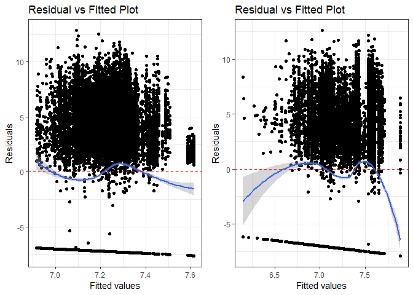

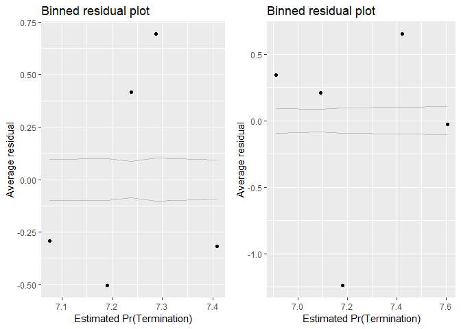

```r
summary_residual_compare(n_Opt_09A,n_Opt_10A, skip_vif =  TRUE)
```

Contrary to expectation on Ceiling breach and otions growth, in line with expectations on terminations.

Level 3 HHI seems to slightly out perform level 6.

#### Model 10B: Defense to Overall ratio

Ratio Def. obligatons : US revenue cl_def3_ratio_lag1+ + + -

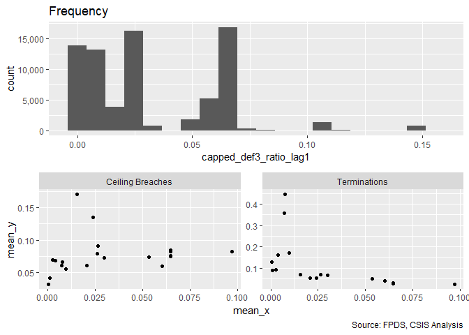

```r
#Frequency Plot for unlogged ceiling
summary_continuous_plot(serv_opt,"capped_def3_ratio_lag1")
```

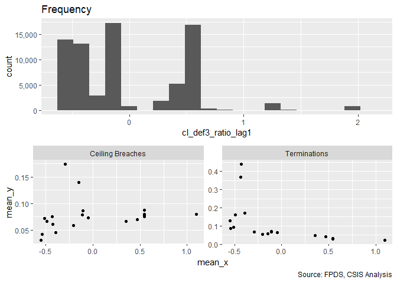

```r
summary_continuous_plot(serv_opt,"cl_def3_ratio_lag1")
```

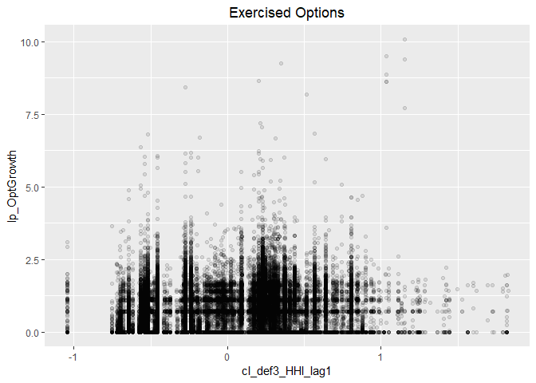

```r
#Scatter Plot
ggplot(serv_opt, aes(x=cl_def3_HHI_lag1, y=lp_OptGrowth)) + geom_point(alpha = 0.1) + ggtitle('Exercised Options') + theme(plot.title = element_text(hjust = 0.5))
```

```r
#Model
n_Opt_10B <- glm (data=serv_opt,
                 ln_OptGrowth ~ cl_def3_ratio_lag1)
display(n_Opt_10B)
```

```
## glm(formula = ln_OptGrowth ~ cl_def3_ratio_lag1, data = serv_opt)
##                    coef.est coef.se
## (Intercept)        7.24     0.02
## cl_def3_ratio_lag1 0.52     0.04
## ---
##   n = 74162, k = 2
##   residual deviance = 2581045.9, null deviance = 2585789.3 (difference = 4743.4)
##   overdispersion parameter = 34.8
##   residual sd is sqrt(overdispersion) = 5.90
```

```r
p_Opt_10B <- glm(data=serv_opt,
                        lp_OptGrowth ~ cl_def3_ratio_lag1)

display(p_Opt_10B)
```

```
## glm(formula = lp_OptGrowth ~ cl_def3_ratio_lag1, data = serv_opt)
##                    coef.est coef.se
## (Intercept)         0.65     0.00
## cl_def3_ratio_lag1 -0.12     0.01
## ---
##   n = 74162, k = 2
##   residual deviance = 34671.4, null deviance = 34944.5 (difference = 273.1)
##   overdispersion parameter = 0.5
##   residual sd is sqrt(overdispersion) = 0.68
```

```r
#Plot residuals versus fitted
stargazer::stargazer(n_Opt_09B,n_Opt_10A,n_Opt_10B,

                       p_Opt_09B,p_Opt_10A,p_Opt_10B,
                       type="text",
                       digits=2)
```

```
##
## =======================================================================================
##                                            Dependent variable:
##                    --------------------------------------------------------------------
##                               ln_OptGrowth                       lp_OptGrowth
##                        (1)         (2)         (3)        (4)        (5)        (6)
## ---------------------------------------------------------------------------------------
## cl_def6_ratio_lag1  -0.45***                            -0.17***
##                      (0.05)                              (0.01)
##
## cl_def3_HHI_lag1                -0.61***                           0.17***
##                                  (0.05)                             (0.01)
##
## cl_def3_ratio_lag1                           0.52***                          -0.12***
##                                              (0.04)                            (0.01)
##
## Constant             7.22***     7.25***     7.24***    0.64***    0.64***    0.65***
##                      (0.02)      (0.02)      (0.02)     (0.003)    (0.003)    (0.003)
##
## ---------------------------------------------------------------------------------------
## Observations         74,162      74,162      74,162      74,162     74,162     74,162
## Log Likelihood     -236,890.90 -236,856.60 -236,858.70 -76,952.11 -76,923.40 -77,038.24
## Akaike Inf. Crit.  473,785.90  473,717.30  473,721.30  153,908.20 153,850.80 154,080.50
## =======================================================================================
## Note:                                                       *p<0.1; **p<0.05; ***p<0.01
```

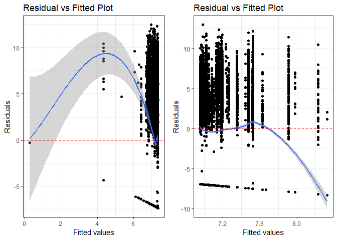

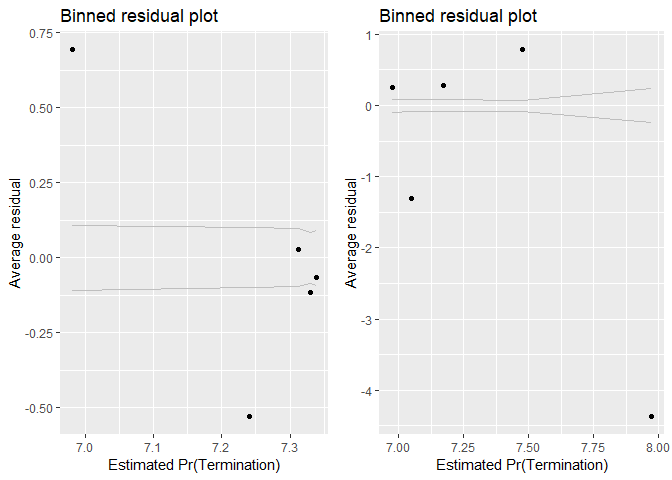

```r
summary_residual_compare(n_Opt_09B,n_Opt_10B, skip_vif = TRUE)
```

#### Model 10C: NAICS 6 and NAICS 3

Consolidation at lessa nd more granular levels may have different effects. Efficiencies are often used to describe sectors, like utilities, with high barriers to entry. Many of these aspects seem like they would already be captured at less granular NAICS levels, e.g. power plants, rather than more specific NAICS levels, like solar vs. coal. As a result, consolidation for more granular NAICS codes should estimate higher rates of ceiling breaches compared to less granular NAICS code.

We’ll start by adding in everything from both models and seeing what violates VIF.

```r
#Frequency Plot for unlogged ceiling



#Model
n_Opt_10C <- glm (data=serv_opt,
                 ln_OptGrowth ~ cl_def3_HHI_lag1+cl_def3_ratio_lag1)
glmer_examine(n_Opt_10C)
```

```
##   cl_def3_HHI_lag1 cl_def3_ratio_lag1
##           1.220506           1.220506
```

```r
p_Opt_10C <- glm(data=serv_opt,
                        lp_OptGrowth ~ cl_def3_HHI_lag1+cl_def3_ratio_lag1)

glmer_examine(p_Opt_10C)
```

```
##   cl_def3_HHI_lag1 cl_def3_ratio_lag1
##           1.220506           1.220506
```

```r
#Plot residuals versus fitted
stargazer::stargazer(n_Opt_09E,n_Opt_10A,n_Opt_10B,n_Opt_10C,

                     p_Opt_09E,p_Opt_10A,p_Opt_10B,p_Opt_10C,
                       type="text",
                       digits=2)
```

```
##
## ==========================================================================================================================
##                                                                    Dependent variable:
##                                -------------------------------------------------------------------------------------------
##                                                 ln_OptGrowth                                  lp_OptGrowth
##                                    (1)         (2)         (3)         (4)        (5)        (6)        (7)        (8)
## --------------------------------------------------------------------------------------------------------------------------
## cl_US6_avg_sal_lag1Const         0.10**                                         -0.03***
##                                  (0.05)                                          (0.01)
##
## cl_CFTE                         -0.80***                                        -0.14***
##                                  (0.05)                                          (0.01)
##
## c_pPBSC                          0.14***                                         -0.01
##                                  (0.05)                                          (0.01)
##
## c_pOffPSC                        0.92***                                        0.22***
##                                  (0.07)                                          (0.01)
##
## c_pairHist                       0.14***                                        -0.01***
##                                  (0.05)                                          (0.01)
##
## cl_pairCA                         0.06                                          0.08***
##                                  (0.06)                                          (0.01)
##
## cl_Ceil                          3.25***                                        0.12***
##                                  (0.05)                                          (0.01)
##
## capped_cl_Days                   1.55***                                        0.04***
##                                  (0.06)                                          (0.01)
##
## Comp1or51 offer                   -0.10                                         0.04***
##                                  (0.06)                                          (0.01)
##
## Comp1or52-4 offers                -0.05                                         0.03***
##                                  (0.06)                                          (0.01)
##
## Comp1or55+ offers                0.47***                                        0.12***
##                                  (0.06)                                          (0.01)
##
```

[output cut: 45 more lines]

```
## cl_def3_HHI_lag1                            -0.61***                -0.43***               0.17***               0.13***
##                                              (0.05)                  (0.06)                 (0.01)                (0.01)
##
## cl_def3_ratio_lag1                                       0.52***     0.36***                          -0.12***   -0.08***
##                                                          (0.04)      (0.05)                            (0.01)     (0.01)
##
## Constant                         6.13***     7.25***     7.24***     7.25***    0.67***    0.64***    0.65***    0.64***
##                                  (0.06)      (0.02)      (0.02)      (0.02)      (0.01)    (0.003)    (0.003)    (0.003)
##
## --------------------------------------------------------------------------------------------------------------------------
## Observations                     74,162      74,162      74,162      74,162      74,162     74,162     74,162     74,162
## Log Likelihood                 -229,315.30 -236,856.60 -236,858.70 -236,829.70 -73,313.05 -76,923.40 -77,038.24 -76,834.45
## Akaike Inf. Crit.              458,684.70  473,717.30  473,721.30  473,665.50  146,680.10 153,850.80 154,080.50 153,674.90
## ==========================================================================================================================
## Note:                                                                                          *p<0.1; **p<0.05; ***p<0.01
```

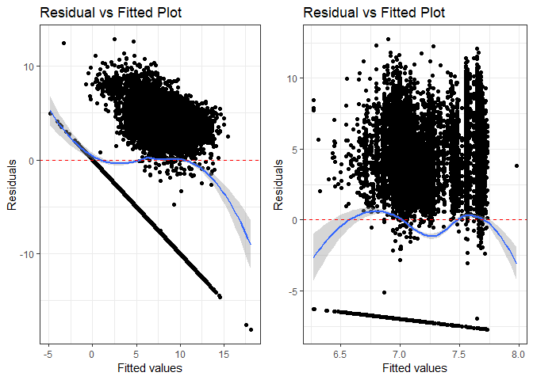

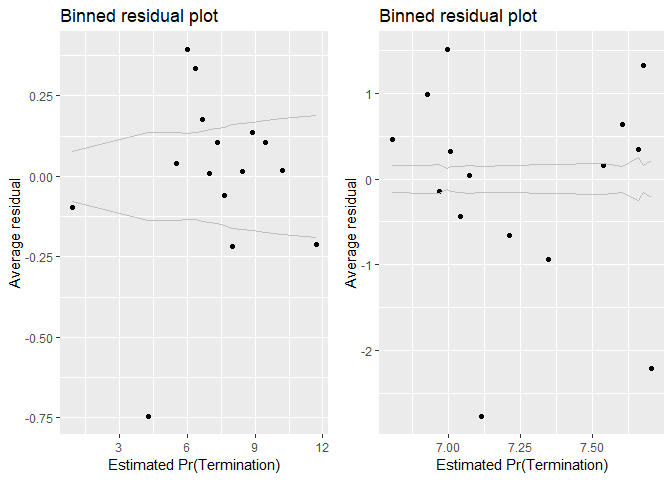

```
## [[1]]
##        model deviance null.deviance difference
## 1 model1_old  2112612       2585789 473177.505
## 2 model1_new  2579032       2585789   6757.384
##
## [[2]]
##   cl_def3_HHI_lag1 cl_def3_ratio_lag1
##           1.220506           1.220506
```

```r
summary_residual_compare(n_Opt_08B,n_Opt_10C)
```

NAICS Subsector (Level 3)  
HHI (logged, + means more consolidation) cl_def3_HHI_lag1+ + ++ - Ratio Def. obligatons : US revenue cl_def3_ratio_lag1+ + + -

Expectations matched for def3_HHI, not matched for ceiling breach or options ratio expectations for ceiling breach and options but not terminations.

#### Model 10D: Cumulative Model

.

```r
#Frequency Plot for unlogged ceiling


#Model
n_Opt_10D <- glm (data=serv_opt,
                 ln_OptGrowth ~  cl_US6_avg_sal_lag1Const +
                   cl_CFTE+ c_pPBSC+c_pOffPSC+
                 c_pairHist+cl_pairCA +
                   cl_Ceil + capped_cl_Days+
                   Comp1or5+
                   Veh+
                   PricingUCA+
                   Crisis+
                   cl_def6_HHI_lag1+cl_def6_ratio_lag1+
                   cl_def3_HHI_lag1+cl_def3_ratio_lag1)
glmer_examine(n_Opt_10D)
```

```
##                              GVIF Df GVIF^(1/(2*Df))
## cl_US6_avg_sal_lag1Const 2.112168  1        1.453330
## cl_CFTE                  1.585528  1        1.259177
## c_pPBSC                  1.331019  1        1.153698
## c_pOffPSC                2.011937  1        1.418428
## c_pairHist               1.557875  1        1.248149
## cl_pairCA                3.262776  1        1.806316
## cl_Ceil                  1.517856  1        1.232013
## capped_cl_Days           1.167574  1        1.080543
## Comp1or5                 1.621610  3        1.083905
## Veh                      3.976009  4        1.188313
## PricingUCA               1.404224  6        1.028694
## Crisis                   1.385758  3        1.055880
## cl_def6_HHI_lag1         1.500778  1        1.225062
## cl_def6_ratio_lag1       1.556282  1        1.247510
## cl_def3_HHI_lag1         1.953989  1        1.397852
## cl_def3_ratio_lag1       2.038070  1        1.427610
```

```r
p_Opt_10D <- glm(data=serv_opt,
                        lp_OptGrowth ~  cl_US6_avg_sal_lag1Const +
                   cl_CFTE+ c_pPBSC+c_pOffPSC+
                 c_pairHist+cl_pairCA+
                 cl_Ceil + capped_cl_Days+
                 Comp1or5+
                   Veh+
                   PricingUCA+
                   Crisis+
                 cl_def6_HHI_lag1+cl_def6_ratio_lag1+
                 cl_def3_HHI_lag1+cl_def3_ratio_lag1)

glmer_examine(p_Opt_10D)
```

```
##                              GVIF Df GVIF^(1/(2*Df))
## cl_US6_avg_sal_lag1Const 2.112168  1        1.453330
## cl_CFTE                  1.585528  1        1.259177
## c_pPBSC                  1.331019  1        1.153698
## c_pOffPSC                2.011937  1        1.418428
## c_pairHist               1.557875  1        1.248149
## cl_pairCA                3.262776  1        1.806316
## cl_Ceil                  1.517856  1        1.232013
## capped_cl_Days           1.167574  1        1.080543
## Comp1or5                 1.621610  3        1.083905
## Veh                      3.976009  4        1.188313
## PricingUCA               1.404224  6        1.028694
## Crisis                   1.385758  3        1.055880
## cl_def6_HHI_lag1         1.500778  1        1.225062
## cl_def6_ratio_lag1       1.556282  1        1.247510
## cl_def3_HHI_lag1         1.953989  1        1.397852
## cl_def3_ratio_lag1       2.038070  1        1.427610
```

```r
#Plot residuals versus fitted
stargazer::stargazer(n_Opt_09E,n_Opt_10C,n_Opt_10D,

                     p_Opt_09E,p_Opt_10C,p_Opt_10D,
                       type="text",
                       digits=2)
```

```
##
## ===================================================================================================
##                                                        Dependent variable:
##                                --------------------------------------------------------------------
##                                           ln_OptGrowth                       lp_OptGrowth
##                                    (1)         (2)         (3)        (4)        (5)        (6)
## ---------------------------------------------------------------------------------------------------
## cl_US6_avg_sal_lag1Const         0.10**                  0.33***    -0.03***              0.04***
##                                  (0.05)                  (0.05)      (0.01)                (0.01)
##
## cl_CFTE                         -0.80***                -0.74***    -0.14***              -0.12***
##                                  (0.05)                  (0.05)      (0.01)                (0.01)
##
## c_pPBSC                          0.14***                 0.12**      -0.01                 -0.01*
##                                  (0.05)                  (0.05)      (0.01)                (0.01)
##
## c_pOffPSC                        0.92***                 0.88***    0.22***               0.20***
##                                  (0.07)                  (0.07)      (0.01)                (0.01)
##
## c_pairHist                       0.14***                 0.18***    -0.01***               -0.01
##                                  (0.05)                  (0.05)      (0.01)                (0.01)
##
## cl_pairCA                         0.06                    -0.04     0.08***               0.05***
##                                  (0.06)                  (0.06)      (0.01)                (0.01)
##
## cl_Ceil                          3.25***                 3.32***    0.12***               0.14***
##                                  (0.05)                  (0.05)      (0.01)                (0.01)
##
## capped_cl_Days                   1.55***                 1.52***    0.04***               0.03***
##                                  (0.06)                  (0.06)      (0.01)                (0.01)
##
## Comp1or51 offer                   -0.10                   -0.10     0.04***               0.04***
##                                  (0.06)                  (0.06)      (0.01)                (0.01)
##
## Comp1or52-4 offers                -0.05                   -0.04     0.03***               0.03***
##                                  (0.06)                  (0.06)      (0.01)                (0.01)
##
## Comp1or55+ offers                0.47***                 0.40***    0.12***               0.11***
##                                  (0.06)                  (0.06)      (0.01)                (0.01)
##
```

[output cut: 45 more lines]

```
## cl_def3_HHI_lag1                            -0.43***     0.40***               0.13***    0.14***
##                                              (0.06)      (0.06)                 (0.01)     (0.01)
##
## cl_def3_ratio_lag1                           0.36***    -0.45***               -0.08***   -0.09***
##                                              (0.05)      (0.06)                 (0.01)     (0.01)
##
## Constant                         6.13***     7.25***     6.06***    0.67***    0.64***    0.65***
##                                  (0.06)      (0.02)      (0.06)      (0.01)    (0.003)     (0.01)
##
## ---------------------------------------------------------------------------------------------------
## Observations                     74,162      74,162      74,162      74,162     74,162     74,162
## Log Likelihood                 -229,315.30 -236,829.70 -229,244.00 -73,313.05 -76,834.45 -72,973.98
## Akaike Inf. Crit.              458,684.70  473,665.50  458,546.00  146,680.10 153,674.90 146,006.00
## ===================================================================================================
## Note:                                                                   *p<0.1; **p<0.05; ***p<0.01
```

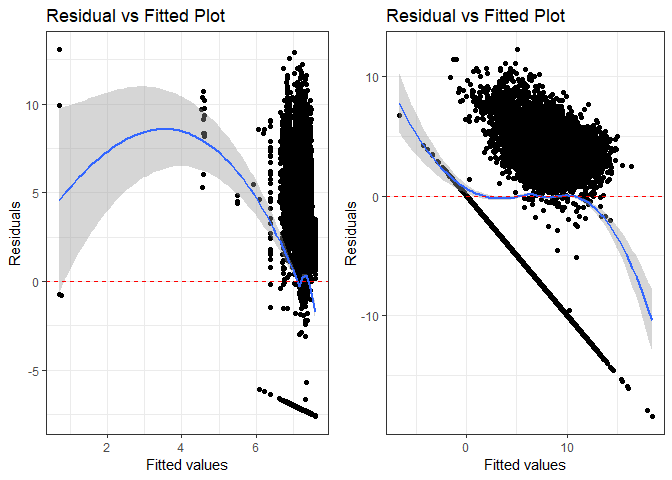

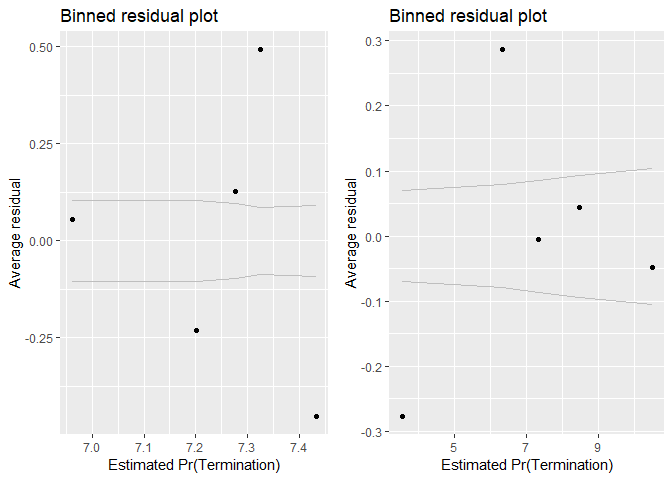

```
## [[1]]
##        model deviance null.deviance difference
## 1 model1_old  2582783       2585789   3006.091
## 2 model1_new  2101902       2585789 483887.678
##
## [[2]]
##                              GVIF Df GVIF^(1/(2*Df))
## cl_US6_avg_sal_lag1Const 2.112168  1        1.453330
## cl_CFTE                  1.585528  1        1.259177
## c_pPBSC                  1.331019  1        1.153698
## c_pOffPSC                2.011937  1        1.418428
## c_pairHist               1.557875  1        1.248149
## cl_pairCA                3.262776  1        1.806316
## cl_Ceil                  1.517856  1        1.232013
## capped_cl_Days           1.167574  1        1.080543
## Comp1or5                 1.621610  3        1.083905
## Veh                      3.976009  4        1.188313
## PricingUCA               1.404224  6        1.028694
## Crisis                   1.385758  3        1.055880
## cl_def6_HHI_lag1         1.500778  1        1.225062
## cl_def6_ratio_lag1       1.556282  1        1.247510
## cl_def3_HHI_lag1         1.953989  1        1.397852
## cl_def3_ratio_lag1       2.038070  1        1.427610
```

```r
summary_residual_compare(n_Opt_09D2,n_Opt_10D)
```

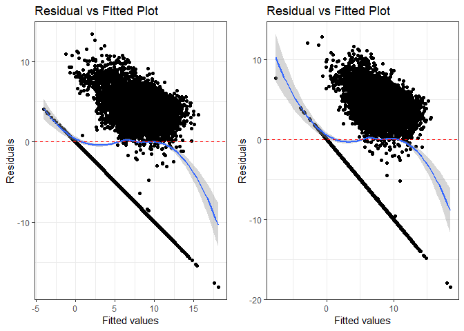

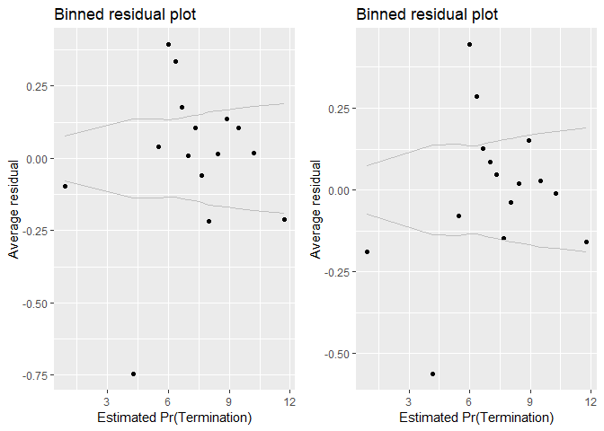

```
## [[1]]
##        model deviance null.deviance difference
## 1 model1_old  2112612       2585789   473177.5
## 2 model1_new  2101902       2585789   483887.7
##
## [[2]]
##                              GVIF Df GVIF^(1/(2*Df))
## cl_US6_avg_sal_lag1Const 2.112168  1        1.453330
## cl_CFTE                  1.585528  1        1.259177
## c_pPBSC                  1.331019  1        1.153698
## c_pOffPSC                2.011937  1        1.418428
## c_pairHist               1.557875  1        1.248149
## cl_pairCA                3.262776  1        1.806316
## cl_Ceil                  1.517856  1        1.232013
## capped_cl_Days           1.167574  1        1.080543
## Comp1or5                 1.621610  3        1.083905
## Veh                      3.976009  4        1.188313
## PricingUCA               1.404224  6        1.028694
## Crisis                   1.385758  3        1.055880
## cl_def6_HHI_lag1         1.500778  1        1.225062
## cl_def6_ratio_lag1       1.556282  1        1.247510
## cl_def3_HHI_lag1         1.953989  1        1.397852
## cl_def3_ratio_lag1       2.038070  1        1.427610
```

```r
summary_residual_compare(n_Opt_08B,n_Opt_10D)
```

HHI6 for ceiling breach now matches expectations but HHI6 for term went in the opposite direction. s

## Office

### Office and Vendor-Office Pair

#### Model 11A: Vendor Market Share

Expectation: Contracts of offices partnered with vendors who have larger market shares would be more likely to experience cost ceiling breaches and exercised options, but less likely to have terminations. Market Share Vendor for that Office c_pMarket ++ - +

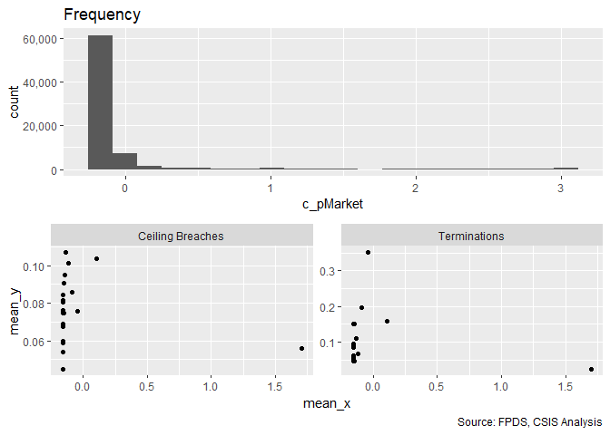

```r
summary_continuous_plot(serv_opt,"c_pMarket")
```

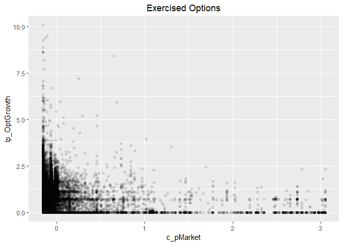

```r
#Scatter Plot
ggplot(serv_opt, aes(x=c_pMarket, y=lp_OptGrowth)) + geom_point(alpha = 0.1) + ggtitle('Exercised Options') + theme(plot.title = element_text(hjust = 0.5))
```

```r
#Model
n_Opt_11A <- glm (data=serv_opt,
                 ln_OptGrowth ~ c_pMarket)
display(n_Opt_11A)
```

```
## glm(formula = ln_OptGrowth ~ c_pMarket, data = serv_opt)
##             coef.est coef.se
## (Intercept)  7.15     0.02
## c_pMarket   -2.40     0.05
## ---
##   n = 74162, k = 2
##   residual deviance = 2495827.5, null deviance = 2585789.3 (difference = 89961.8)
##   overdispersion parameter = 33.7
##   residual sd is sqrt(overdispersion) = 5.80
```

```r
p_Opt_11A <- glm(data=serv_opt,
                        lp_OptGrowth ~ c_pMarket)

display(p_Opt_11A)
```

```
## glm(formula = lp_OptGrowth ~ c_pMarket, data = serv_opt)
##             coef.est coef.se
## (Intercept)  0.64     0.00
## c_pMarket   -0.24     0.01
## ---
##   n = 74162, k = 2
##   residual deviance = 34074.9, null deviance = 34944.5 (difference = 869.6)
##   overdispersion parameter = 0.5
##   residual sd is sqrt(overdispersion) = 0.68
```

```r
#Plot residuals versus fitted
stargazer::stargazer(n_Opt_11A,

                       p_Opt_11A,
                       type="text",
                       digits=2)
```

```
##
## ==============================================
##                       Dependent variable:
##                   ----------------------------
##                    ln_OptGrowth  lp_OptGrowth
##                        (1)            (2)
## ----------------------------------------------
## c_pMarket            -2.40***      -0.24***
##                       (0.05)        (0.01)
##
## Constant             7.15***        0.64***
##                       (0.02)        (0.002)
##
## ----------------------------------------------
## Observations          74,162        74,162
## Log Likelihood     -235,613.70    -76,394.74
## Akaike Inf. Crit.   471,231.40    152,793.50
## ==============================================
## Note:              *p<0.1; **p<0.05; ***p<0.01
```

Aligns with expectations on terminatio, but not for ceiling breach or for options.

#### Model 11B: Cumulative Model

```r
#Frequency Plot for unlogged ceiling


#Model
n_Opt_11B <- glm (data=serv_opt,
                 ln_OptGrowth ~  cl_US6_avg_sal_lag1Const +
                   cl_CFTE+ c_pPBSC+c_pOffPSC+
                 c_pairHist+cl_pairCA +
                   cl_Ceil + capped_cl_Days+
                   Comp1or5+
                   Veh+
                   PricingUCA+
                   Crisis+
                   cl_def6_HHI_lag1+cl_def6_ratio_lag1+
                   cl_def3_HHI_lag1+cl_def3_ratio_lag1+
                   c_pMarket)
glmer_examine(n_Opt_11B)
```

```
##                              GVIF Df GVIF^(1/(2*Df))
## cl_US6_avg_sal_lag1Const 2.123524  1        1.457232
## cl_CFTE                  1.585951  1        1.259345
## c_pPBSC                  1.343786  1        1.159218
## c_pOffPSC                2.021151  1        1.421672
## c_pairHist               1.558115  1        1.248245
## cl_pairCA                3.695001  1        1.922239
## cl_Ceil                  1.519123  1        1.232527
## capped_cl_Days           1.191396  1        1.091511
## Comp1or5                 1.655631  3        1.087662
## Veh                      4.036247  4        1.190549
## PricingUCA               1.406303  6        1.028821
## Crisis                   1.747371  3        1.097482
## cl_def6_HHI_lag1         1.502498  1        1.225764
## cl_def6_ratio_lag1       1.557323  1        1.247927
## cl_def3_HHI_lag1         1.958297  1        1.399392
## cl_def3_ratio_lag1       2.086319  1        1.444409
## c_pMarket                2.008805  1        1.417323
```

```r
p_Opt_11B <- glm(data=serv_opt,
                        lp_OptGrowth ~  cl_US6_avg_sal_lag1Const +
                   cl_CFTE+ c_pPBSC+c_pOffPSC+
                 c_pairHist+cl_pairCA+
                 cl_Ceil + capped_cl_Days+
                 Comp1or5+
                   Veh+
                   PricingUCA+
                   Crisis+
                 cl_def6_HHI_lag1+cl_def6_ratio_lag1+
                 cl_def3_HHI_lag1+cl_def3_ratio_lag1+
                 c_pMarket)

glmer_examine(p_Opt_11B)
```

```
##                              GVIF Df GVIF^(1/(2*Df))
## cl_US6_avg_sal_lag1Const 2.123524  1        1.457232
## cl_CFTE                  1.585951  1        1.259345
## c_pPBSC                  1.343786  1        1.159218
## c_pOffPSC                2.021151  1        1.421672
## c_pairHist               1.558115  1        1.248245
## cl_pairCA                3.695001  1        1.922239
## cl_Ceil                  1.519123  1        1.232527
## capped_cl_Days           1.191396  1        1.091511
## Comp1or5                 1.655631  3        1.087662
## Veh                      4.036247  4        1.190549
## PricingUCA               1.406303  6        1.028821
## Crisis                   1.747371  3        1.097482
## cl_def6_HHI_lag1         1.502498  1        1.225764
## cl_def6_ratio_lag1       1.557323  1        1.247927
## cl_def3_HHI_lag1         1.958297  1        1.399392
## cl_def3_ratio_lag1       2.086319  1        1.444409
## c_pMarket                2.008805  1        1.417323
```

```r
#Plot residuals versus fitted
stargazer::stargazer(n_Opt_10D,n_Opt_11A,n_Opt_11B,

                     p_Opt_10D,p_Opt_11A,p_Opt_11B,
                       type="text",
                       digits=2)
```

```
##
## ===================================================================================================
##                                                        Dependent variable:
##                                --------------------------------------------------------------------
##                                           ln_OptGrowth                       lp_OptGrowth
##                                    (1)         (2)         (3)        (4)        (5)        (6)
## ---------------------------------------------------------------------------------------------------
## cl_US6_avg_sal_lag1Const         0.33***                 0.23***    0.04***               0.02***
##                                  (0.05)                  (0.05)      (0.01)                (0.01)
##
## cl_CFTE                         -0.74***                -0.72***    -0.12***              -0.11***
##                                  (0.05)                  (0.05)      (0.01)                (0.01)
##
## c_pPBSC                          0.12**                   -0.01      -0.01*               -0.03***
##                                  (0.05)                  (0.05)      (0.01)                (0.01)
##
## c_pOffPSC                        0.88***                 0.75***    0.20***               0.18***
##                                  (0.07)                  (0.07)      (0.01)                (0.01)
##
## c_pairHist                       0.18***                 0.16***     -0.01                 -0.01
##                                  (0.05)                  (0.05)      (0.01)                (0.01)
##
## cl_pairCA                         -0.04                  0.60***    0.05***               0.14***
##                                  (0.06)                  (0.07)      (0.01)                (0.01)
##
## cl_Ceil                          3.32***                 3.36***    0.14***               0.14***
##                                  (0.05)                  (0.05)      (0.01)                (0.01)
##
## capped_cl_Days                   1.52***                 1.27***    0.03***               -0.0004
##                                  (0.06)                  (0.06)      (0.01)                (0.01)
##
## Comp1or51 offer                   -0.10                   0.08      0.04***               0.06***
##                                  (0.06)                  (0.06)      (0.01)                (0.01)
##
## Comp1or52-4 offers                -0.04                   -0.04     0.03***               0.03***
##                                  (0.06)                  (0.06)      (0.01)                (0.01)
##
## Comp1or55+ offers                0.40***                 0.32***    0.11***               0.10***
##                                  (0.06)                  (0.06)      (0.01)                (0.01)
##
```

[output cut: 48 more lines]

```
## cl_def3_ratio_lag1              -0.45***                -0.20***    -0.09***              -0.06***
##                                  (0.06)                  (0.06)      (0.01)                (0.01)
##
## c_pMarket                                   -2.40***    -1.68***               -0.24***   -0.22***
##                                              (0.05)      (0.06)                 (0.01)     (0.01)
##
## Constant                         6.06***     7.15***     6.17***    0.65***    0.64***    0.66***
##                                  (0.06)      (0.02)      (0.06)      (0.01)    (0.002)     (0.01)
##
## ---------------------------------------------------------------------------------------------------
## Observations                     74,162      74,162      74,162      74,162     74,162     74,162
## Log Likelihood                 -229,244.00 -235,613.70 -228,855.20 -72,973.98 -76,394.74 -72,517.08
## Akaike Inf. Crit.              458,546.00  471,231.40  457,770.40  146,006.00 152,793.50 145,094.20
## ===================================================================================================
## Note:                                                                   *p<0.1; **p<0.05; ***p<0.01
```

```r
#summary_residual_compare(n_Opt_10D,n_Opt_11B)
#summary_residual_compare(n_Opt_11A,n_Opt_11B)
```

Note that the VIF is getting high on pair_CA.